# Customer Segmentation

Benard Omido

2024-09-03

###### This project involves the analysis of an online retail store data set obtained from the UCI Machine Learning Repository. The data set contains transactional data for two years; 2010 and 2011. Main objective of this project is to boost sales through customer segmentation, using the K-means clustering algorithm.

```r
library(tidyverse)
```

Load the data

```r
ecommerce <- read_csv("Ecommerce.csv")
glimpse(ecommerce)
```

```
## Rows: 541,909
## Columns: 8
## $ InvoiceNo   <chr> "536365", "536365", "536365", "536365", "536365", "536365"…
## $ StockCode   <chr> "85123A", "71053", "84406B", "84029G", "84029E", "22752", …
## $ Description <chr> "WHITE HANGING HEART T-LIGHT HOLDER", "WHITE METAL LANTERN…
## $ Quantity    <dbl> 6, 6, 8, 6, 6, 2, 6, 6, 6, 32, 6, 6, 8, 6, 6, 3, 2, 3, 3, …
## $ InvoiceDate <chr> "12/1/2010 8:26", "12/1/2010 8:26", "12/1/2010 8:26", "12/…
## $ UnitPrice   <dbl> 2.55, 3.39, 2.75, 3.39, 3.39, 7.65, 4.25, 1.85, 1.85, 1.69…
## $ CustomerID  <dbl> 17850, 17850, 17850, 17850, 17850, 17850, 17850, 17850, 17…
## $ Country     <chr> "United Kingdom", "United Kingdom", "United Kingdom", "Uni…
```

**Data set Overview**

**Data Exploration**

```r
# Missing values and Duplicates

colSums(is.na(ecommerce))     # The description column contains 1454 missing values where as the customer ID column contains 135080 missing values
```

```
##   InvoiceNo   StockCode Description    Quantity InvoiceDate   UnitPrice
##           0           0        1454           0           0           0
##  CustomerID     Country
##      135080           0
```

```r
ecommerce %>%
  group_by(InvoiceNo, StockCode, Description, CustomerID, InvoiceDate,
           Country, UnitPrice, Quantity) %>%
  summarize(n = n()) %>%
  filter(n > 1)             # There 4,879 duplicates in the data
```

```
## # A tibble: 4,879 × 9
## # Groups:   InvoiceNo, StockCode, Description, CustomerID, InvoiceDate,
## #   Country, UnitPrice [4,867]
##    InvoiceNo StockCode Description      CustomerID InvoiceDate Country UnitPrice
##    <chr>     <chr>     <chr>                 <dbl> <chr>       <chr>       <dbl>
##  1 536409    21866     UNION JACK FLAG…      17908 12/1/2010 … United…      1.25
##  2 536409    22111     SCOTTIE DOG HOT…      17908 12/1/2010 … United…      4.95
##  3 536409    22866     HAND WARMER SCO…      17908 12/1/2010 … United…      2.1
##  4 536409    22900     SET 2 TEA TOWEL…      17908 12/1/2010 … United…      2.95
##  5 536412    21448     12 DAISY PEGS I…      17920 12/1/2010 … United…      1.65
##  6 536412    21448     12 DAISY PEGS I…      17920 12/1/2010 … United…      1.65
##  7 536412    21706     FOLDING UMBRELL…      17920 12/1/2010 … United…      4.95
##  8 536412    21708     FOLDING UMBRELL…      17920 12/1/2010 … United…      4.95
##  9 536412    22141     CHRISTMAS CRAFT…      17920 12/1/2010 … United…      2.1
## 10 536412    22273     FELTCRAFT DOLL …      17920 12/1/2010 … United…      2.95
## # ℹ 4,869 more rows
## # ℹ 2 more variables: Quantity <dbl>, n <int>
```

```r
skimr::skim(ecommerce)
```

Data summary

| Name | ecommerce |
| --- | --- |
| Number of rows | 541909 |
| Number of columns | 8 |
| _______________________ |  |
| Column type frequency: |  |
| character | 5 |
| numeric | 3 |
| ________________________ |  |
| Group variables | None |

**Variable type: character**

| skim_variable | n_missing | complete_rate | min | max | empty | n_unique | whitespace |
| --- | --- | --- | --- | --- | --- | --- | --- |
| InvoiceNo | 0 | 1 | 6 | 7 | 0 | 25900 | 0 |
| StockCode | 0 | 1 | 1 | 12 | 0 | 4070 | 0 |
| Description | 1454 | 1 | 1 | 35 | 0 | 4211 | 0 |
| InvoiceDate | 0 | 1 | 13 | 16 | 0 | 23260 | 0 |
| Country | 0 | 1 | 3 | 20 | 0 | 38 | 0 |

**Variable type: numeric**

| skim_variable | n_missing | complete_rate | mean | sd | p0 | p25 | p50 | p75 | p100 | hist |
| --- | --- | --- | --- | --- | --- | --- | --- | --- | --- | --- |
| Quantity | 0 | 1.00 | 9.55 | 218.08 | -80995.00 | 1.00 | 3.00 | 10.00 | 80995 | ▁▁▇▁▁ |
| UnitPrice | 0 | 1.00 | 4.61 | 96.76 | -11062.06 | 1.25 | 2.08 | 4.13 | 38970 | ▁▇▁▁▁ |
| CustomerID | 135080 | 0.75 | 15287.69 | 1713.60 | 12346.00 | 13953.00 | 15152.00 | 16791.00 | 18287 | ▇▇▇▇▇ |

```r
# There are 25,900 unique invoices, which represents 25,900 different transactions
# There are 4070 unique stock codes, this represents the number of unique products sold
# The description column is 99.73% complete, contains missing value, as we had seen above
# There are 23260 unique invoice dates
# Products had been sold in 38 different countries
# The average quantity of products in a transaction was 9.5. Notably, the quantity column has a minimum of -80995 which indicates the presence of cancelled or returned values, where as the maximum number of products in a single transaction was 80995. The huge gap between the upper quartile and the maximum indicates the presence of outliers.
# The average unit price in a transaction was 4.61, with a minimum of -11062.06. This may represent the cancelled orders. The maximum unit price was 38970, which indicates the presence of outliers due to the large difference between it and the upper quartile
# The customer ID column had a completion rate of 75.07%
```

**Data Cleaning and Transformation**

```r
# Handling Missing values
# The rows with missing values in the customer ID and description columns are removed. This is because imputing missing customer ID values, which will be an important variable in the clustering algorithm, might introduce bias

ecommerce <- ecommerce %>%
  na.omit()

ecommerce
```

```
## # A tibble: 406,829 × 8
##    InvoiceNo StockCode Description     Quantity InvoiceDate UnitPrice CustomerID
##    <chr>     <chr>     <chr>              <dbl> <chr>           <dbl>      <dbl>
##  1 536365    85123A    WHITE HANGING …        6 12/1/2010 …      2.55      17850
##  2 536365    71053     WHITE METAL LA…        6 12/1/2010 …      3.39      17850
##  3 536365    84406B    CREAM CUPID HE…        8 12/1/2010 …      2.75      17850
##  4 536365    84029G    KNITTED UNION …        6 12/1/2010 …      3.39      17850
##  5 536365    84029E    RED WOOLLY HOT…        6 12/1/2010 …      3.39      17850
##  6 536365    22752     SET 7 BABUSHKA…        2 12/1/2010 …      7.65      17850
##  7 536365    21730     GLASS STAR FRO…        6 12/1/2010 …      4.25      17850
##  8 536366    22633     HAND WARMER UN…        6 12/1/2010 …      1.85      17850
##  9 536366    22632     HAND WARMER RE…        6 12/1/2010 …      1.85      17850
## 10 536367    84879     ASSORTED COLOU…       32 12/1/2010 …      1.69      13047
## # ℹ 406,819 more rows
## # ℹ 1 more variable: Country <chr>
```

```r
# Handling Duplicates
# The completely identical rows in the data might introduce noise in the data, which might hinder the accuracy of the clustering algorithm

#ecommerce_df <- ecommerce %>%
#  group_by(InvoiceNo, StockCode, Description, CustomerID, InvoiceDate,
#           Country, UnitPrice, Quantity) %>%
#  summarize(n = n()) %>%
#  mutate(rnk = row_number(n)) %>%
#  filter(rnk == 1) %>%
#  ungroup() %>%
#  dplyr::select(-c(n, rnk))

ecommerce <-  ecommerce %>%
  group_by(InvoiceNo, StockCode, Description, CustomerID, InvoiceDate,
           Country, UnitPrice, Quantity) %>%
  distinct() %>% ungroup()

ecommerce
```

```
## # A tibble: 401,604 × 8
##    InvoiceNo StockCode Description     Quantity InvoiceDate UnitPrice CustomerID
##    <chr>     <chr>     <chr>              <dbl> <chr>           <dbl>      <dbl>
##  1 536365    85123A    WHITE HANGING …        6 12/1/2010 …      2.55      17850
##  2 536365    71053     WHITE METAL LA…        6 12/1/2010 …      3.39      17850
##  3 536365    84406B    CREAM CUPID HE…        8 12/1/2010 …      2.75      17850
##  4 536365    84029G    KNITTED UNION …        6 12/1/2010 …      3.39      17850
##  5 536365    84029E    RED WOOLLY HOT…        6 12/1/2010 …      3.39      17850
##  6 536365    22752     SET 7 BABUSHKA…        2 12/1/2010 …      7.65      17850
##  7 536365    21730     GLASS STAR FRO…        6 12/1/2010 …      4.25      17850
##  8 536366    22633     HAND WARMER UN…        6 12/1/2010 …      1.85      17850
##  9 536366    22632     HAND WARMER RE…        6 12/1/2010 …      1.85      17850
## 10 536367    84879     ASSORTED COLOU…       32 12/1/2010 …      1.69      13047
## # ℹ 401,594 more rows
## # ℹ 1 more variable: Country <chr>
```

```r
# Handling Cancelled orders
# In order to get a better understanding of customer behavior and preferences, we need to take into account transactions that were cancelled
# Cancelled transactions have invoices starting with C

canceled_transactions <- str_subset(ecommerce$InvoiceNo, "^C")

ecommerce %>%
  filter(InvoiceNo %in% canceled_transactions) %>%
  summary()
```

```
##   InvoiceNo          StockCode         Description           Quantity
##  Length:8872        Length:8872        Length:8872        Min.   :-80995.00
##  Class :character   Class :character   Class :character   1st Qu.:    -6.00
##  Mode  :character   Mode  :character   Mode  :character   Median :    -2.00
##                                                           Mean   :   -30.77
##                                                           3rd Qu.:    -1.00
##                                                           Max.   :    -1.00
##  InvoiceDate          UnitPrice          CustomerID      Country
##  Length:8872        Min.   :    0.01   Min.   :12346   Length:8872
##  Class :character   1st Qu.:    1.45   1st Qu.:13505   Class :character
##  Mode  :character   Median :    2.95   Median :14868   Mode  :character
##                     Mean   :   18.90   Mean   :14990
##                     3rd Qu.:    4.95   3rd Qu.:16393
##                     Max.   :38970.00   Max.   :18282
```

```r
# All quantities in the cancelled transactions are negative, indicating that indeed these are cancelled transactions
```

```r
# Creating stock code anomalies
# Plotting the top 10 unique most common stock codes

#unique(ecommerce$StockCode)
n_distinct(ecommerce$StockCode)  # The number of unique stock codes is 3684
```

```
## [1] 3684
```

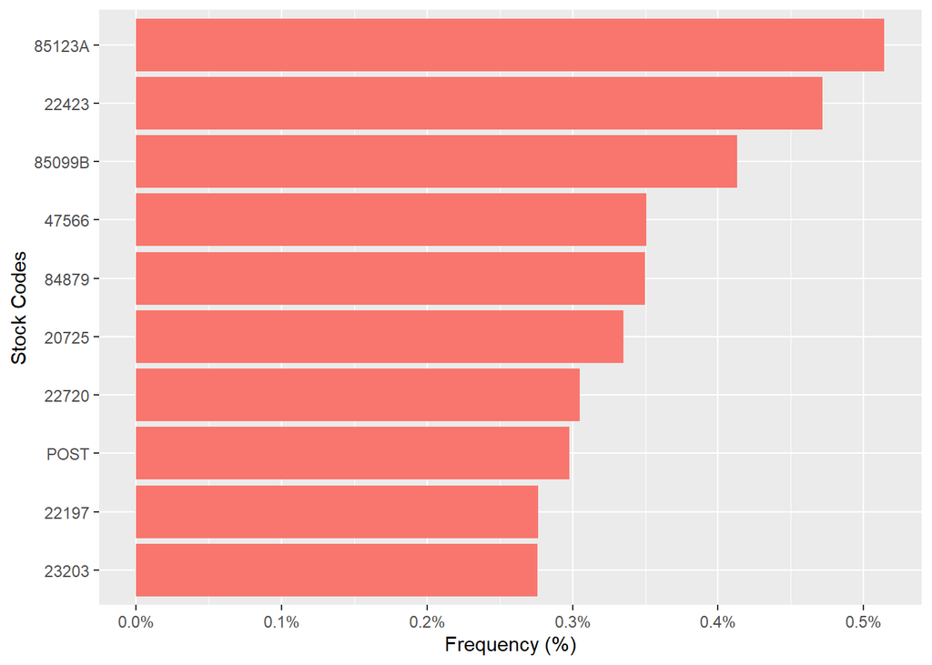

```r
ecommerce %>%
  group_by(StockCode) %>%
  summarize(n = n()) %>%
  mutate(prop = n / sum(n)) %>%
  slice_max(prop, n = 10) %>%
  ggplot(aes(prop, fct_reorder(StockCode, prop), fill = "midnightblue")) +
  geom_col(show.legend = FALSE) +
  scale_x_continuous(labels = scales::percent_format()) +
  labs(x = "Frequency (%)",
       y = "Stock Codes")
```

Most stock codes are composed of 5 or 6 characters, though there are some anomalies, e.g ‘POST’

```r
# Investigating the stock codes with anomalies
# These anomalies might represent services or non-product transactions (perhaps postage fees) rather than actual products. To maintain the focus of the project, which is clustering based on product purchases and creating a recommendation system, these anomalies should be removed to ensure focus remains strictly on genuine product transactions, which would lead to a more accurate and meaningful analysis.

distinct_codes <- unique(ecommerce$StockCode)

num_chars <- nchar(distinct_codes)

# tibble
stock_codes_char_counts <- tibble(
  distinct_codes = distinct_codes,
  num_chars = num_chars
)

stock_codes_char_counts %>% count(num_chars, sort = TRUE)
```

```
## # A tibble: 8 × 2
##   num_chars     n
##       <int> <int>
## 1         5  2798
## 2         6   877
## 3         4     3
## 4         1     2
## 5         2     1
## 6         3     1
## 7         7     1
## 8        12     1
```

2798 codes have 5 characters, 877 have 6 characters, 3 have 4 characters, while others have 1, 2, 3, 7, and 12 characters

```r
# codes that contain zero and 1 numeric characters

# Function to count numeric characters in a string
count_digits <- function(x) {
  sum(str_count(x, "\\d"))
}

count_digits("2356H")
```

```
## [1] 4
```

```r
# Filter StockCodes that have either zero or one numeric character
non_numeric_codes <- distinct_codes[sapply(distinct_codes, count_digits) <= 1]

non_numeric_codes
```

```
## [1] "POST"         "D"            "C2"           "M"            "BANK CHARGES"
## [6] "PADS"         "DOT"          "CRUK"
```

```r
# Removing these anomalous codes
ecommerce <- ecommerce %>%
  filter(!StockCode %in% non_numeric_codes)

ecommerce
```

```
## # A tibble: 399,689 × 8
##    InvoiceNo StockCode Description     Quantity InvoiceDate UnitPrice CustomerID
##    <chr>     <chr>     <chr>              <dbl> <chr>           <dbl>      <dbl>
##  1 536365    85123A    WHITE HANGING …        6 12/1/2010 …      2.55      17850
##  2 536365    71053     WHITE METAL LA…        6 12/1/2010 …      3.39      17850
##  3 536365    84406B    CREAM CUPID HE…        8 12/1/2010 …      2.75      17850
##  4 536365    84029G    KNITTED UNION …        6 12/1/2010 …      3.39      17850
##  5 536365    84029E    RED WOOLLY HOT…        6 12/1/2010 …      3.39      17850
##  6 536365    22752     SET 7 BABUSHKA…        2 12/1/2010 …      7.65      17850
##  7 536365    21730     GLASS STAR FRO…        6 12/1/2010 …      4.25      17850
##  8 536366    22633     HAND WARMER UN…        6 12/1/2010 …      1.85      17850
##  9 536366    22632     HAND WARMER RE…        6 12/1/2010 …      1.85      17850
## 10 536367    84879     ASSORTED COLOU…       32 12/1/2010 …      1.69      13047
## # ℹ 399,679 more rows
## # ℹ 1 more variable: Country <chr>
```

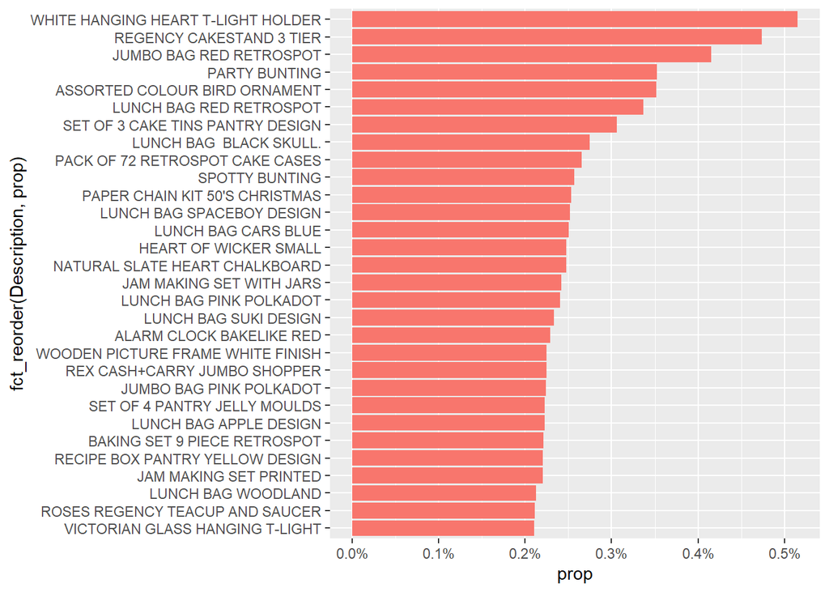

```r
# Cleaning the description column

ecommerce %>%
  group_by(Description) %>%
  summarize(n = n()) %>%
  mutate(prop = n / sum(n)) %>%
  slice_max(prop, n = 30) %>%
  ggplot(aes(prop, fct_reorder(Description,prop), fill = "steelblue")) +
  geom_col(show.legend = FALSE) +
  scale_x_continuous(labels = scales::percent_format())
```

```r
descriptions_unique <- unique(ecommerce$Description)

ecommerce %>%
  filter(str_detect(Description, "[a-z]")) %>%
  group_by(Description) %>% summarise(n = n())
```

```
## # A tibble: 19 × 2
##    Description                             n
##    <chr>                               <int>
##  1 3 TRADITIONAl BISCUIT CUTTERS  SET    207
##  2 BAG 125g SWIRLY MARBLES               252
##  3 BAG 250g SWIRLY MARBLES               201
##  4 BAG 500g SWIRLY MARBLES               115
##  5 ESSENTIAL BALM 3.5g TIN IN ENVELOPE    18
##  6 FLOWERS HANDBAG blue and orange         3
##  7 FOLK ART GREETING CARD,pack/12         10
##  8 FRENCH BLUE METAL DOOR SIGN No         75
##  9 High Resolution Image                   3
## 10 NUMBER TILE COTTAGE GARDEN No          12
## 11 NUMBER TILE VINTAGE FONT No             7
## 12 Next Day Carriage                      80
## 13 POLYESTER FILLER PAD 30CMx30CM         26
## 14 POLYESTER FILLER PAD 40x40cm          185
## 15 POLYESTER FILLER PAD 45x30cm           37
## 16 POLYESTER FILLER PAD 45x45cm          135
## 17 POLYESTER FILLER PAD 60x40cm            1
## 18 POLYESTER FILLER PAD 65CMx65CM          5
## 19 THE KING GIFT BAG 25x24x12cm            7
```

```r
# The description column contains some non product descriptions, e.g High resolution Image

# Removing these descriptions
servixe_related_descriptions <- c("High Resolution Image", "Next Day Carriage")


ecommerce <- ecommerce %>%
  filter(!Description %in% servixe_related_descriptions)
```

```r
# Cleaning the unit price column

summary(ecommerce$UnitPrice)  # The minimum unit price is zero, which indicates some data errors in transactions
```

```
##    Min. 1st Qu.  Median    Mean 3rd Qu.    Max.
##   0.000   1.250   1.950   2.905   3.750 649.500
```

```r
# Removing them
ecommerce <- ecommerce %>%
  filter(UnitPrice != 0)

ecommerce
```

```
## # A tibble: 399,573 × 8
##    InvoiceNo StockCode Description     Quantity InvoiceDate UnitPrice CustomerID
##    <chr>     <chr>     <chr>              <dbl> <chr>           <dbl>      <dbl>
##  1 536365    85123A    WHITE HANGING …        6 12/1/2010 …      2.55      17850
##  2 536365    71053     WHITE METAL LA…        6 12/1/2010 …      3.39      17850
##  3 536365    84406B    CREAM CUPID HE…        8 12/1/2010 …      2.75      17850
##  4 536365    84029G    KNITTED UNION …        6 12/1/2010 …      3.39      17850
##  5 536365    84029E    RED WOOLLY HOT…        6 12/1/2010 …      3.39      17850
##  6 536365    22752     SET 7 BABUSHKA…        2 12/1/2010 …      7.65      17850
##  7 536365    21730     GLASS STAR FRO…        6 12/1/2010 …      4.25      17850
##  8 536366    22633     HAND WARMER UN…        6 12/1/2010 …      1.85      17850
##  9 536366    22632     HAND WARMER RE…        6 12/1/2010 …      1.85      17850
## 10 536367    84879     ASSORTED COLOU…       32 12/1/2010 …      1.69      13047
## # ℹ 399,563 more rows
## # ℹ 1 more variable: Country <chr>
```

**Feature Engineering**

- To create a comprehensive customer centric data set for clustering and recommendation, the following features were calculated from the data:

**RFM Features** - RFM is a method for analyzing customer value and segmenting the customer base.

-**Recency (R)** - This metric indicates how recently a customer has made a purchase. A lower recency value means the customer has purchased more recently, indicating higher engagement with the brand

- **Frequency (F)** - This metric signifies how often a customer makes a purchase within a certain period. A higher frequency value indicates a customer who interacts with the business more often, suggesting higher loyalty or satisfaction
- **Monetary (M)**- This metrics represents the total amount of money a customer has spent over a certain period of time. Customers who have a higher monetary value have contributed more to the business, indicating their potential high life time value
- These metrics help in understanding a customer’s buying preferences and behavior, which is important in personalizing marketing strategies and creating a recommendation system

**Recency**

- In this step, we focus on understanding how recently a customer has made a purchase.
- By understanding the recency of purchases, businesses can tailor their marketing strategies to re-engage customers who have not made purchases in a while, potentially increasing customer retention and fostering loyalty.

```r
# convert Invoice date column to date time type
class(ecommerce$InvoiceDate)
```

```
## [1] "character"
```

```r
head(ecommerce$InvoiceDate)
```

```
## [1] "12/1/2010 8:26" "12/1/2010 8:26" "12/1/2010 8:26" "12/1/2010 8:26"
## [5] "12/1/2010 8:26" "12/1/2010 8:26"
```

```r
ecommerce <- ecommerce %>%
  mutate(InvoiceDate = parse_date_time(InvoiceDate, orders = "mdy_HM"))

# Find the most recent purchase data for each customer

customer_data <- ecommerce %>%
  group_by(CustomerID) %>%
  summarize(most_recent_purchase_date = max(date(InvoiceDate)))

customer_data
```

```
## # A tibble: 4,362 × 2
##    CustomerID most_recent_purchase_date
##         <dbl> <date>
##  1      12346 2011-01-18
##  2      12347 2011-12-07
##  3      12348 2011-09-25
##  4      12349 2011-11-21
##  5      12350 2011-02-02
##  6      12352 2011-11-03
##  7      12353 2011-05-19
##  8      12354 2011-04-21
##  9      12355 2011-05-09
## 10      12356 2011-11-17
## # ℹ 4,352 more rows
```

```r
# Find the most recent date in entire data
most_recent_date <- max(ecommerce$InvoiceDate)
most_recent_date
```

```
## [1] "2011-12-09 12:50:00 UTC"
```

```r
# calculate the number of days since the last purchase for each customer
customer_data <- customer_data %>%
  mutate(Days_since_last_purchase = as.Date(most_recent_date) - most_recent_purchase_date,
         Days_since_last_purchase = str_remove(Days_since_last_purchase, "days")) %>%
  dplyr::select(-most_recent_purchase_date)

customer_data
```

```
## # A tibble: 4,362 × 2
##    CustomerID Days_since_last_purchase
##         <dbl> <chr>
##  1      12346 325
##  2      12347 2
##  3      12348 75
##  4      12349 18
##  5      12350 310
##  6      12352 36
##  7      12353 204
##  8      12354 232
##  9      12355 214
## 10      12356 22
## # ℹ 4,352 more rows
```

**Frequency**

- This step involves calculation of two features that quantify the frequency of a customer’s engagement with the retailer
- Total transactions - this represents the total number of transactions made by a customer
- Total products purchased - This represents the total number of products purchased by a customer across all transactions. It gives insights into into the customer’s buying behavior in terms of the volumes of products purchased

```r
# calculate total number of transactions made by each customer

total_transactions <- ecommerce %>%
  group_by(CustomerID) %>%
  summarize(total_transactions = n_distinct(InvoiceNo))

# calculate total number of products purchased by each customer
total_products <- ecommerce %>%
  group_by(CustomerID) %>%
  summarize(total_products = sum(Quantity))

# Merge with the customer_data data set
customer_data <- customer_data %>%
  bind_cols(total_transactions) %>%
  bind_cols(total_products) %>%
  mutate(CustomerID = CustomerID...1) %>%
  dplyr::select(-c(CustomerID...1, CustomerID...3, CustomerID...5)) %>%
  dplyr::select(CustomerID, everything())

customer_data
```

```
## # A tibble: 4,362 × 4
##    CustomerID Days_since_last_purchase total_transactions total_products
##         <dbl> <chr>                                 <int>          <dbl>
##  1      12346 325                                       2              0
##  2      12347 2                                         7           2458
##  3      12348 75                                        4           2332
##  4      12349 18                                        1            630
##  5      12350 310                                       1            196
##  6      12352 36                                        8            463
##  7      12353 204                                       1             20
##  8      12354 232                                       1            530
##  9      12355 214                                       1            240
## 10      12356 22                                        3           1573
## # ℹ 4,352 more rows
```

**Monetary**

- This step involves calculation of two features:
- Total Spend - Represents the total amount of money spent by each customer. This feature is important as it helps in identifying the total revenue generated by each customer, which is a direct indicator of a customer’s value to the business
- Average Transaction Value - It indicates the average value of a transaction carried out by a customer. This metric is useful in understanding the spending behavior of customers per transaction, which can assist in tailoring marketing strategies and offers to different customer segments based on their average spending patterns.

```r
# calculate total amount spent by each customer
total_spend <- ecommerce %>%
  group_by(CustomerID) %>%
  summarize(total_spend = sum(Quantity * UnitPrice))

# average amount per transaction
customer_data <- customer_data %>%
  inner_join(total_spend, by = "CustomerID") %>%
  mutate(average_transaction_value = total_spend / total_transactions)

customer_data
```

```
## # A tibble: 4,362 × 6
##    CustomerID Days_since_last_purchase total_transactions total_products
##         <dbl> <chr>                                 <int>          <dbl>
##  1      12346 325                                       2              0
##  2      12347 2                                         7           2458
##  3      12348 75                                        4           2332
##  4      12349 18                                        1            630
##  5      12350 310                                       1            196
##  6      12352 36                                        8            463
##  7      12353 204                                       1             20
##  8      12354 232                                       1            530
##  9      12355 214                                       1            240
## 10      12356 22                                        3           1573
## # ℹ 4,352 more rows
## # ℹ 2 more variables: total_spend <dbl>, average_transaction_value <dbl>
```

**Product Diversity**

- This step helps us understand the diversity in product purchase behavior of customers
- Unique products purchased - this feature represents the number of distinct products bought by a customer. A higher value indicates that the customer has a diverse taste or preference, buying a wide range of products, while a lower value might indicate a focused or specific preference. Understanding the diversity in product purchases can help in segmenting customers based on their buying diversity, which can be a critical input in personalizing product recommendations

```r
unique_products_purchased <- ecommerce %>%
  group_by(CustomerID) %>%
  summarize(unique_products = n_distinct(StockCode))

# Merge with customer_data
customer_data <- customer_data %>%
  inner_join(unique_products_purchased, by = "CustomerID")
customer_data
```

```
## # A tibble: 4,362 × 7
##    CustomerID Days_since_last_purchase total_transactions total_products
##         <dbl> <chr>                                 <int>          <dbl>
##  1      12346 325                                       2              0
##  2      12347 2                                         7           2458
##  3      12348 75                                        4           2332
##  4      12349 18                                        1            630
##  5      12350 310                                       1            196
##  6      12352 36                                        8            463
##  7      12353 204                                       1             20
##  8      12354 232                                       1            530
##  9      12355 214                                       1            240
## 10      12356 22                                        3           1573
## # ℹ 4,352 more rows
## # ℹ 3 more variables: total_spend <dbl>, average_transaction_value <dbl>,
## #   unique_products <int>
```

**Behavioral Features**

- In this step, we aim to understand and capture the shopping patterns and behaviors of customers. These features will give us insights into the customers’ preferences regarding when they like to shop, which can be crucial information for personalizing their shopping experience.
- Average days between purchases - This feature represents the average number of days a customer waits before making another purchase. Understanding this can help in predicting when the customer is likely to make their next purchase, which can be a crucial metric for targeted marketing and personalized promotions.
- Favorite shopping day - This denotes the day of the week when the customer shops the most. This information can help in identifying the preferred shopping days of different customer segments, which can be used to optimize marketing strategies and promotions for different days of the week.
- Favorite Shopping Hour: This refers to the hour of the day when the customer shops the most. Identifying the favorite shopping hour can aid in optimizing the timing of marketing campaigns and promotions to align with the times when different customer segments are most active
- By including these behavioral features in our dataset, we can create a more rounded view of our customers, which will potentially enhance the effectiveness of the clustering algorithm, leading to more meaningful customer segments.

```r
# Extract day and hour from Invoice data column
day_hour <- ecommerce %>%
  mutate(day = wday(InvoiceDate),
         Hour = hour(InvoiceDate))

# Number of days between consecutive purchases
days_btwn_purchases <- ecommerce %>%
  group_by(CustomerID) %>%
  mutate(Days_between_purchases = as.numeric(difftime(date(InvoiceDate),
                                                      lag(date(InvoiceDate)), units = "days"))) %>% ungroup()

average_days_btwn_purchases <- days_btwn_purchases %>%
  group_by(CustomerID) %>%
  summarize(avg_days_btwn_purchases = mean(Days_between_purchases, na.rm = TRUE))

average_days_btwn_purchases
```

```
## # A tibble: 4,362 × 2
##    CustomerID avg_days_btwn_purchases
##         <dbl>                   <dbl>
##  1      12346                    0
##  2      12347                    2.02
##  3      12348                   10.9
##  4      12349                    0
##  5      12350                    0
##  6      12352                    3.13
##  7      12353                    0
##  8      12354                    0
##  9      12355                    0
## 10      12356                    5.32
## # ℹ 4,352 more rows
```

```r
# Favorite shopping day
favorite_shopping_day <- day_hour %>%
  group_by(CustomerID, day) %>%
  summarize(count = n()) %>%
  ungroup() %>%
  group_by(CustomerID) %>%
  filter(count == max(count)) %>%
  arrange(CustomerID, day) %>%
  slice(1) %>%
  dplyr::select(CustomerID, day)

favorite_shopping_day
```

```
## # A tibble: 4,362 × 2
## # Groups:   CustomerID [4,362]
##    CustomerID   day
##         <dbl> <dbl>
##  1      12346     3
##  2      12347     3
##  3      12348     5
##  4      12349     2
##  5      12350     4
##  6      12352     3
##  7      12353     5
##  8      12354     5
##  9      12355     2
## 10      12356     3
## # ℹ 4,352 more rows
```

```r
# Favorite shopping hour of the day

favorite_shopping_hour <- day_hour %>%
  group_by(CustomerID, Hour) %>%
  summarize(count = n()) %>%
  ungroup() %>%
  group_by(CustomerID) %>%
  filter(count == max(count)) %>%
  arrange(CustomerID, Hour) %>%
  slice(1) %>%
  dplyr::select(CustomerID, Hour)

favorite_shopping_hour
```

```
## # A tibble: 4,362 × 2
## # Groups:   CustomerID [4,362]
##    CustomerID  Hour
##         <dbl> <int>
##  1      12346    10
##  2      12347    14
##  3      12348    19
##  4      12349     9
##  5      12350    16
##  6      12352    14
##  7      12353    17
##  8      12354    13
##  9      12355    13
## 10      12356     9
## # ℹ 4,352 more rows
```

```r
# Merge with customers data
customer_data <- customer_data %>%
  inner_join(average_days_btwn_purchases, by = "CustomerID") %>%
  inner_join(favorite_shopping_day, by = "CustomerID") %>%
  inner_join(favorite_shopping_hour, by = "CustomerID")

# Fill NA values in avg_days_btwn_purchases column with 0
customer_data <- customer_data %>%
  mutate(avg_days_btwn_purchases = if_else(is.na(avg_days_btwn_purchases), 0, avg_days_btwn_purchases))


colSums(is.na(customer_data))
```

```
##                CustomerID  Days_since_last_purchase        total_transactions
##                         0                         0                         0
##            total_products               total_spend average_transaction_value
##                         0                         0                         0
##           unique_products   avg_days_btwn_purchases                       day
##                         0                         0                         0
##                      Hour
##                         0
```

```r
customer_data
```

```
## # A tibble: 4,362 × 10
##    CustomerID Days_since_last_purchase total_transactions total_products
##         <dbl> <chr>                                 <int>          <dbl>
##  1      12346 325                                       2              0
##  2      12347 2                                         7           2458
##  3      12348 75                                        4           2332
##  4      12349 18                                        1            630
##  5      12350 310                                       1            196
##  6      12352 36                                        8            463
##  7      12353 204                                       1             20
##  8      12354 232                                       1            530
##  9      12355 214                                       1            240
## 10      12356 22                                        3           1573
## # ℹ 4,352 more rows
## # ℹ 6 more variables: total_spend <dbl>, average_transaction_value <dbl>,
## #   unique_products <int>, avg_days_btwn_purchases <dbl>, day <dbl>, Hour <int>
```

**Geographic Features**

- We introduce a geographic feature that reflects the geographical location of the customer
- Country - Including the country data can help us understand region-specific buying patterns and preferences. Different regions might have varying preferences and purchasing behaviors which can be critical in personalizing marketing strategies and inventory planning. Furthermore, it can be instrumental in logistics and supply chain optimization, particularly for an online retailer where shipping and delivery play a significant role.

```r
ecommerce %>%
  count(Country, sort = TRUE) %>%
  mutate(percetage = round(n / sum(n), 2))
```

```
## # A tibble: 37 × 3
##    Country             n percetage
##    <chr>           <int>     <dbl>
##  1 United Kingdom 356008      0.89
##  2 Germany          9079      0.02
##  3 France           8152      0.02
##  4 EIRE             7368      0.02
##  5 Spain            2462      0.01
##  6 Netherlands      2326      0.01
##  7 Belgium          1971      0
##  8 Switzerland      1843      0
##  9 Portugal         1427      0
## 10 Australia        1253      0
## # ℹ 27 more rows
```

```r
# 89% of the transactions are of the United Kingdom
# Since majority of the transactions are of the UK, we can create a binary feature that is represented by 1 if the transcation is of UK

country_of_transaction <- ecommerce %>%
  group_by(CustomerID, Country) %>%
  summarize(number_of_transactions = n()) %>%   # number of transactions per customer per country
  ungroup() %>%
  group_by(CustomerID) %>%
  filter(number_of_transactions == max(number_of_transactions)) %>%   # extract maximum number of transactions made by a customer
  mutate(Is_UK = if_else(Country == "United Kingdom", 1, 0)) %>%
  dplyr::select(CustomerID, Is_UK)

country_of_transaction %>%
  group_by(Is_UK) %>% summarize(n = n())
```

```
## # A tibble: 2 × 2
##   Is_UK     n
##   <dbl> <int>
## 1     0   420
## 2     1  3942
```

```r
# Merge with customer data
customer_data <- customer_data %>%
  inner_join(country_of_transaction, by = "CustomerID")

customer_data
```

```
## # A tibble: 4,362 × 11
##    CustomerID Days_since_last_purchase total_transactions total_products
##         <dbl> <chr>                                 <int>          <dbl>
##  1      12346 325                                       2              0
##  2      12347 2                                         7           2458
##  3      12348 75                                        4           2332
##  4      12349 18                                        1            630
##  5      12350 310                                       1            196
##  6      12352 36                                        8            463
##  7      12353 204                                       1             20
##  8      12354 232                                       1            530
##  9      12355 214                                       1            240
## 10      12356 22                                        3           1573
## # ℹ 4,352 more rows
## # ℹ 7 more variables: total_spend <dbl>, average_transaction_value <dbl>,
## #   unique_products <int>, avg_days_btwn_purchases <dbl>, day <dbl>,
## #   Hour <int>, Is_UK <dbl>
```

**Cancellation Insights**

- Cancellation Frequency - This metric represents the total number of transactions a customer has canceled. Understanding the frequency of cancellations can help us identify customers who are more likely to cancel transactions. This could be an indicator of dissatisfaction or other issues, and understanding this can help us tailor strategies to reduce cancellations and enhance customer satisfaction.
- Cancellation Rate: This represents the proportion of transactions that a customer has canceled out of all their transactions. This metric gives a normalized view of cancellation behavior. A high cancellation rate might be indicative of an unsatisfied customer segment. By identifying these segments, we can develop targeted strategies to improve their shopping experience and potentially reduce the cancellation rate.

```r
# Total number of transactions made by each customer
total_transactions <- ecommerce %>%
  group_by(CustomerID) %>%
  summarize(num_transactions = n_distinct(InvoiceNo))


# Total number of cancelled transactions for each customer
ecommerce <- ecommerce %>%
  mutate(Transaction_status = if_else(str_detect(InvoiceNo, "^C"), "Cancelled", "Completed"))

cancelled_transactions <- ecommerce %>%
  count(CustomerID, Transaction_status) %>%
  group_by(CustomerID) %>%
  filter(Transaction_status == "Cancelled") %>%
  ungroup()

head(cancelled_transactions)
```

```
## # A tibble: 6 × 3
##   CustomerID Transaction_status     n
##        <dbl> <chr>              <int>
## 1      12346 Cancelled              1
## 2      12352 Cancelled              7
## 3      12359 Cancelled              6
## 4      12362 Cancelled              8
## 5      12375 Cancelled              1
## 6      12379 Cancelled              1
```

```r
# Merge with customers data
customer_data <- customer_data %>%
  left_join(cancelled_transactions, by = "CustomerID") %>%
  dplyr::select(-Transaction_status) %>%
  rename(Cancellation_frequency = n) %>%
  mutate(Cancellation_frequency = if_else(is.na(Cancellation_frequency), 0,    Cancellation_frequency))

# Calculate cancellation rate
customer_data <- customer_data %>%
  mutate(Cancellation_rate = Cancellation_frequency / total_transactions)

customer_data
```

```
## # A tibble: 4,362 × 13
##    CustomerID Days_since_last_purchase total_transactions total_products
##         <dbl> <chr>                                 <int>          <dbl>
##  1      12346 325                                       2              0
##  2      12347 2                                         7           2458
##  3      12348 75                                        4           2332
##  4      12349 18                                        1            630
##  5      12350 310                                       1            196
##  6      12352 36                                        8            463
##  7      12353 204                                       1             20
##  8      12354 232                                       1            530
##  9      12355 214                                       1            240
## 10      12356 22                                        3           1573
## # ℹ 4,352 more rows
## # ℹ 9 more variables: total_spend <dbl>, average_transaction_value <dbl>,
## #   unique_products <int>, avg_days_btwn_purchases <dbl>, day <dbl>,
## #   Hour <int>, Is_UK <dbl>, Cancellation_frequency <dbl>,
## #   Cancellation_rate <dbl>
```

**Seasonality & Trends**

- This step delves into the seasonality and trends in customers’ purchasing behaviors, which can offer invaluable insights for tailoring marketing strategies and enhancing customer satisfaction.
- Monthly_Spending_Mean: This is the average amount a customer spends monthly. It helps us gauge the general spending habit of each customer. A higher mean indicates a customer who spends more, potentially showing interest in premium products, whereas a lower mean might indicate a more budget-conscious customer.
- Monthly_Spending_Std: This feature indicates the variability in a customer’s monthly spending. A higher value signals that the customer’s spending fluctuates significantly month-to-month, perhaps indicating sporadic large purchases. In contrast, a lower value suggests more stable, consistent spending habits. Understanding this variability can help in crafting personalized promotions or discounts during periods they are expected to spend more.
- Spending_Trend: This reflects the trend in a customer’s spending over time, calculated as the slope of the linear trend line fitted to their spending data. A positive value indicates an increasing trend in spending, possibly pointing to growing loyalty or satisfaction. Conversely, a negative trend might signal decreasing interest or satisfaction, highlighting a need for re-engagement strategies. A near-zero value signifies stable spending habits. Recognizing these trends can help in developing strategies to either maintain or alter customer spending patterns, enhancing the effectiveness of marketing campaigns.

By incorporating these detailed insights into our customer segmentation model, we can create more precise and actionable customer groups, facilitating the development of highly targeted marketing strategies and promotions.

```r
# Extract month and year
month_year <- ecommerce %>%
  mutate(month = month(InvoiceDate),
         year = year(InvoiceDate))

# Monthly spending for each customer
monthly_spending <- month_year %>%
  group_by(CustomerID, year, month) %>%
  summarize(monthly_spending = sum(UnitPrice * Quantity)) %>%
  ungroup()

monthly_spending
```

```
## # A tibble: 13,621 × 4
##    CustomerID  year month monthly_spending
##         <dbl> <dbl> <dbl>            <dbl>
##  1      12346  2011     1               0
##  2      12347  2010    12             712.
##  3      12347  2011     1             475.
##  4      12347  2011     4             636.
##  5      12347  2011     6             383.
##  6      12347  2011     8             585.
##  7      12347  2011    10            1294.
##  8      12347  2011    12             225.
##  9      12348  2010    12             653.
## 10      12348  2011     1             187.
## # ℹ 13,611 more rows
```

```r
# Seasonal buying patterns
seasonal_buying_patterns <- monthly_spending %>%
  group_by(CustomerID) %>%
  summarize(monthly_spending_mean = mean(monthly_spending, na.rm = TRUE),
            monthly_spending_std = sd(monthly_spending, na.rm = TRUE)) %>%
  ungroup()

seasonal_buying_patterns
```

```
## # A tibble: 4,362 × 3
##    CustomerID monthly_spending_mean monthly_spending_std
##         <dbl>                 <dbl>                <dbl>
##  1      12346                    0                   NA
##  2      12347                  616.                 341.
##  3      12348                  359.                 204.
##  4      12349                 1458.                  NA
##  5      12350                  294.                  NA
##  6      12352                  316.                 135.
##  7      12353                   89                   NA
##  8      12354                 1079.                  NA
##  9      12355                  459.                  NA
## 10      12356                  829.                 991.
## # ℹ 4,352 more rows
```

```r
#Replace NA values in monthly_spending_std column
seasonal_buying_patterns <- seasonal_buying_patterns %>%
  mutate(monthly_spending_std = if_else(is.na(monthly_spending_std), 0, monthly_spending_std))


# Calculating spend trends

calculate_trend <- function(spend_data){
  if(length(spend_data) > 1){
    x <- seq_along(spend_data)   #Generate sequence for time points
    model <- lm(spend_data~x)    #Fit linear model
    return(coef(model)[["x"]])   #Return the slope (trend)
  }
  else{
    return(0)
  }
}

# Apply the above function to each customer's spending data
spending_trends <- monthly_spending %>%
  group_by(CustomerID) %>%
  summarize(spending_trend = calculate_trend(monthly_spending)) %>%
  ungroup()

spending_trends
```

```
## # A tibble: 4,362 × 2
##    CustomerID spending_trend
##         <dbl>          <dbl>
##  1      12346           0
##  2      12347           4.49
##  3      12348        -101.
##  4      12349           0
##  5      12350           0
##  6      12352           9.35
##  7      12353           0
##  8      12354           0
##  9      12355           0
## 10      12356        -945.
## # ℹ 4,352 more rows
```

```r
# Explaining the above function

# The calculate_trend() function is designed to calculate the trend (slope) of a customer's spending over time. The slope is a measure of how a customer's spending changes from one time period (e.g., month) to the next.

# spend_data is the input to the function. It represents a vector of spending values for a customer over different time periods (e.g., monthly spending amounts).

# The function first checks if there is more than one data point in spend_data.
#If there is only one data point (e.g., spending data for just one month), a trend cannot be calculated. So, the function will return 0 for such cases.

# seq_along(spend_data) - generates a sequence of integers from 1 to the length of spend_data.
# This sequence represents the time periods for the spending data (e.g., the 1st month, 2nd month, etc.).

# lm(spend_data ~ x) - fits a simple linear regression model, where spend_data is the dependent variable (y-axis) and x is the independent variable (x-axis).
# This model essentially tries to fit a straight line through the data points, with the goal of finding the best-fitting line that explains how spending changes over time.

# coef(model)[["x"]] extracts the slope of the fitted line from the linear model.
# A positive slope means spending is increasing over time.
# A negative slope means spending is decreasing over time.
# A slope of zero indicates that spending is stable, with no upward or downward trend.



# Merge with the customers data
customer_data <- customer_data %>%
  inner_join(seasonal_buying_patterns, by = "CustomerID") %>%
  inner_join(spending_trends, by = "CustomerID")

customer_data
```

```
## # A tibble: 4,362 × 16
##    CustomerID Days_since_last_purchase total_transactions total_products
##         <dbl> <chr>                                 <int>          <dbl>
##  1      12346 325                                       2              0
##  2      12347 2                                         7           2458
##  3      12348 75                                        4           2332
##  4      12349 18                                        1            630
##  5      12350 310                                       1            196
##  6      12352 36                                        8            463
##  7      12353 204                                       1             20
##  8      12354 232                                       1            530
##  9      12355 214                                       1            240
## 10      12356 22                                        3           1573
## # ℹ 4,352 more rows
## # ℹ 12 more variables: total_spend <dbl>, average_transaction_value <dbl>,
## #   unique_products <int>, avg_days_btwn_purchases <dbl>, day <dbl>,
## #   Hour <int>, Is_UK <dbl>, Cancellation_frequency <dbl>,
## #   Cancellation_rate <dbl>, monthly_spending_mean <dbl>,
## #   monthly_spending_std <dbl>, spending_trend <dbl>
```

```r
# Change data type for customer id and Days since last purchase

customer_data <- customer_data %>%
  mutate(CustomerID = as.character(CustomerID),
         Days_since_last_purchase = as.numeric(Days_since_last_purchase))

customer_data
```

```
## # A tibble: 4,362 × 16
##    CustomerID Days_since_last_purchase total_transactions total_products
##    <chr>                         <dbl>              <int>          <dbl>
##  1 12346                           325                  2              0
##  2 12347                             2                  7           2458
##  3 12348                            75                  4           2332
##  4 12349                            18                  1            630
##  5 12350                           310                  1            196
##  6 12352                            36                  8            463
##  7 12353                           204                  1             20
##  8 12354                           232                  1            530
##  9 12355                           214                  1            240
## 10 12356                            22                  3           1573
## # ℹ 4,352 more rows
## # ℹ 12 more variables: total_spend <dbl>, average_transaction_value <dbl>,
## #   unique_products <int>, avg_days_btwn_purchases <dbl>, day <dbl>,
## #   Hour <int>, Is_UK <dbl>, Cancellation_frequency <dbl>,
## #   Cancellation_rate <dbl>, monthly_spending_mean <dbl>,
## #   monthly_spending_std <dbl>, spending_trend <dbl>
```

##### **Customer Dataset Description:**

**Variable Description**

**CustomerID** - Identifier uniquely assigned to each customer, used to distinguish individual customers.

**Days_Since_Last_Purchase** - The number of days that have passed since the customer’s last purchase.

**Total_Transactions** - The total number of transactions made by the customer.

**Total_Products_Purchased** - The total quantity of products purchased by the customer across all transactions.

**Total_Spend** - The total amount of money the customer has spent across all transactions.

**Average_Transaction_Value** - The average value of the customer’s transactions, calculated as total spend divided by the number of transactions.

**Unique_Products_Purchased** - The number of different products the customer has purchased.

**Average_Days_Between_Purchases** - The average number of days between consecutive purchases made by the customer.

**Day_Of_Week** - The day of the week when the customer prefers to shop, represented numerically

**Hour** - The hour of the day when the customer prefers to shop, represented in a 24-hour format.

**Is_UK** - A binary variable indicating whether the customer is based in the UK (1) or not (0).

**Cancellation_Frequency** - The total number of transactions that the customer has cancelled.

**Cancellation_Rate** - The proportion of transactions that the customer has cancelled, calculated as cancellation frequency divided by total transactions.

**Monthly_Spending_Mean** - The average monthly spending of the customer.

**Monthly_Spending_Std** - The standard deviation of the customer’s monthly spending, indicating the variability in their spending pattern.

**Spending_Trend** - A numerical representation of the trend in the customer’s spending over time. A positive value indicates an increasing trend, a negative value indicates a decreasing trend, and a value close to zero indicates a stable trend.

**Outlier detection and prevention**

```r
# First approach using the isolation forest model

#library(isotree)

#model <- isolation.forest(customer_data[, -1], ntrees = 100, sample_size = 256, nthreads = 1, seed = 123, prob_pick_pooled_gain = 0.05)

# Predict outliers

#customer_data$Outlier_Scores <- predict(model, customer_data[, -1])

# Create a new column to identify outliers (1 for inliers and 0 for outliers)

#customer_data$Is_Outlier <- ifelse(customer_data$Outlier_Scores == 1, 0, 1)

#customer_data



# Using Mahalanobis Distance to Detect Outliers

library(MASS)


# Extract numeric features (assuming CustomerID is in the first column)
numeric_data <- customer_data[, -1]


# Compute the covariance matrix and mean of the numeric data
cov_matrix <- cov(numeric_data)
mean_vector <- colMeans(numeric_data)

# Compute the Mahalanobis distance for each row in the dataset
customer_data$Mahalanobis_Dist <- mahalanobis(numeric_data, center = mean_vector, cov = cov_matrix)

customer_data
```

```
## # A tibble: 4,362 × 17
##    CustomerID Days_since_last_purchase total_transactions total_products
##    <chr>                         <dbl>              <int>          <dbl>
##  1 12346                           325                  2              0
##  2 12347                             2                  7           2458
##  3 12348                            75                  4           2332
##  4 12349                            18                  1            630
##  5 12350                           310                  1            196
##  6 12352                            36                  8            463
##  7 12353                           204                  1             20
##  8 12354                           232                  1            530
##  9 12355                           214                  1            240
## 10 12356                            22                  3           1573
## # ℹ 4,352 more rows
## # ℹ 13 more variables: total_spend <dbl>, average_transaction_value <dbl>,
## #   unique_products <int>, avg_days_btwn_purchases <dbl>, day <dbl>,
## #   Hour <int>, Is_UK <dbl>, Cancellation_frequency <dbl>,
## #   Cancellation_rate <dbl>, monthly_spending_mean <dbl>,
## #   monthly_spending_std <dbl>, spending_trend <dbl>, Mahalanobis_Dist <dbl>
```

```r
# Define the threshold for identifying outliers
# Use chi-squared distribution to set a threshold (e.g., p-value = 0.975 for 95% confidence)
# df = number of columns used in Mahalanobis distance (dimensionality of the data)
threshold <- qchisq(0.975, df = ncol(numeric_data))
threshold
```

```
## [1] 27.48839
```

```r
# Label observations as outliers based on the Mahalanobis distance
customer_data <- customer_data %>%
  mutate(Is_Outlier = ifelse(Mahalanobis_Dist > threshold, 1, 0))

customer_data %>%
  count(Is_Outlier)
```

```
## # A tibble: 2 × 2
##   Is_Outlier     n
##        <dbl> <int>
## 1          0  4160
## 2          1   202
```

```r
customer_data %>%
  filter(Is_Outlier == 1)
```

```
## # A tibble: 202 × 18
##    CustomerID Days_since_last_purchase total_transactions total_products
##    <chr>                         <dbl>              <int>          <dbl>
##  1 12357                            33                  1           2708
##  2 12378                           129                  1           2529
##  3 12406                            22                  3           1809
##  4 12409                            78                  7           5543
##  5 12415                            24                 24          76946
##  6 12428                            25                 11           3477
##  7 12432                            42                  4           1800
##  8 12433                             0                  7          11071
##  9 12435                            79                  2           2055
## 10 12438                            14                  2           1169
## # ℹ 192 more rows
## # ℹ 14 more variables: total_spend <dbl>, average_transaction_value <dbl>,
## #   unique_products <int>, avg_days_btwn_purchases <dbl>, day <dbl>,
## #   Hour <int>, Is_UK <dbl>, Cancellation_frequency <dbl>,
## #   Cancellation_rate <dbl>, monthly_spending_mean <dbl>,
## #   monthly_spending_std <dbl>, spending_trend <dbl>, Mahalanobis_Dist <dbl>,
## #   Is_Outlier <dbl>
```

**Isolation Forest**

- An Isolation Forest is a machine learning model designed specifically for anomaly detection, which works by isolating observations in a dataset. The basic idea is that anomalies are few and different, so they are more susceptible to isolation.
- ntrees - This parameter specifies the number of trees to grow in the isolation forest. A higher number of trees can improve the model’s accuracy but also increases computation time
- sample_size - This parameter determines the number of samples (data points) to be used for each tree in the forest. A smaller sample size can make the trees less accurate but faster to compute. The default value often used is 256, which is a good balance between computational efficiency and model accuracy.
- nthreads - This parameter specifies the number of threads to use for parallel processing. If you set this to a value higher than 1, the model can take advantage of multiple CPU cores to speed up computation. Setting nthreads = 1 means the model will run on a single core.
- prob_pick_pooled_gain - This parameter controls the “contamination” level or the expected proportion of outliers in the dataset. A lower value (like 0.05) suggests that the model should assume that around 5% of the data points are outliers. This setting influences how aggressively the model identifies outliers.

**Mahalanobis Distance (Multivariate Outliers)**

- For multivariate data, Mahalanobis distance helps detect outliers by measuring the distance between a point and the distribution of all other points.

```r
# Removing outliers if present

# Separate the outliers for analysis
outliers_data <- customer_data[customer_data$Is_Outlier == 1, ]

# Remove the outliers from the main dataset
customer_data_cleaned <- customer_data[customer_data$Is_Outlier == 0, ]

# Drop the Mahalanobis_Dist and 'Is_Outlier' columns
customer_data_cleaned <- customer_data_cleaned %>%
    dplyr::select(-c(Mahalanobis_Dist, Is_Outlier))

customer_data_cleaned
```

```
## # A tibble: 4,160 × 16
##    CustomerID Days_since_last_purchase total_transactions total_products
##    <chr>                         <dbl>              <int>          <dbl>
##  1 12346                           325                  2              0
##  2 12347                             2                  7           2458
##  3 12348                            75                  4           2332
##  4 12349                            18                  1            630
##  5 12350                           310                  1            196
##  6 12352                            36                  8            463
##  7 12353                           204                  1             20
##  8 12354                           232                  1            530
##  9 12355                           214                  1            240
## 10 12356                            22                  3           1573
## # ℹ 4,150 more rows
## # ℹ 12 more variables: total_spend <dbl>, average_transaction_value <dbl>,
## #   unique_products <int>, avg_days_btwn_purchases <dbl>, day <dbl>,
## #   Hour <int>, Is_UK <dbl>, Cancellation_frequency <dbl>,
## #   Cancellation_rate <dbl>, monthly_spending_mean <dbl>,
## #   monthly_spending_std <dbl>, spending_trend <dbl>
```

**Correlation Analysis**

- The presence of multicollinearity, where features are highly correlated, can potentially affect the clustering process by not allowing the model to learn the actual underlying patterns in the data, as the features do not provide unique information. This could lead to clusters that are not well-separated and meaningful.
- If we identify multicollinearity, we can utilize dimensionality reduction techniques like PCA. These techniques help in neutralizing the effect of multicollinearity by transforming the correlated features into a new set of uncorrelated variables, preserving most of the original data’s variance. This step not only enhances the quality of clusters formed but also makes the clustering process more computationally efficient.

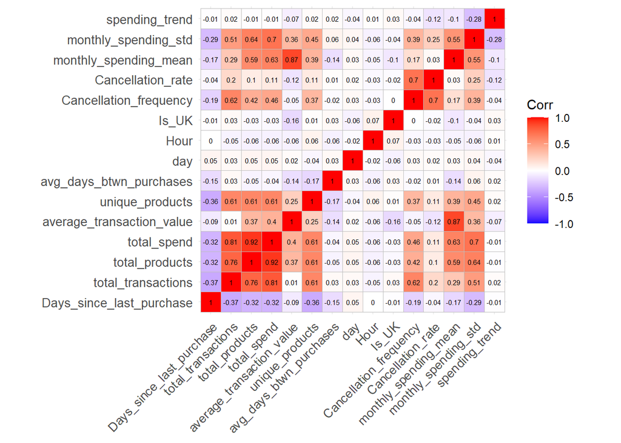

```r
library(ggcorrplot)
customer_data_cleaned %>%
  select_if(is.numeric) %>%
  cor(use = "complete.obs") %>%
  ggcorrplot(method = "square",
             type = "full", lab = TRUE, lab_size = 2, tl.cex = 10)
```

There are some highly correlated variables in the data. For example: Total spend vs total products purchased Total transactions vs Total spend e.t.c

**Handling Multicollinearity through PCA**

**Data Preparation - Feature Scaling**

Before we move forward with the clustering and dimensionality reduction, it’s imperative to scale our features. This step holds significant importance, especially in the context of distance-based algorithms like K-means and dimensionality reduction methods like PCA. Here’s why:

- For K-means Clustering: K-means relies heavily on the concept of ‘distance’ between data points to form clusters. When features are not on a similar scale, features with larger values can disproportionately influence the clustering outcome, potentially leading to incorrect groupings.
- For PCA: PCA aims to find the directions where the data varies the most. When features are not scaled, those with larger values might dominate these components, not accurately reflecting the underlying patterns in the data.

**PCA**

```r
# List of columns that don't need to be scaled

columns_to_exclude <- c('CustomerID', 'Is_UK', 'day')

# List of columns that need to be scaled (excluding the ones that don't need scaling)
columns_to_scale <- setdiff(names(customer_data_cleaned), columns_to_exclude)

# Copy the cleaned dataset
customer_data_scaled <- customer_data_cleaned

# Apply scaling to the necessary columns in the dataset
customer_data_scaled[columns_to_scale] <- scale(customer_data_cleaned[columns_to_scale])

head(customer_data_scaled)
```

```
## # A tibble: 6 × 16
##   CustomerID Days_since_last_purchase total_transactions total_products
##   <chr>                         <dbl>              <dbl>          <dbl>
## 1 12346                         2.29             -0.467         -0.689
## 2 12347                        -0.903             0.578          1.64
## 3 12348                        -0.181            -0.0488         1.52
## 4 12349                        -0.745            -0.676         -0.0927
## 5 12350                         2.15             -0.676         -0.503
## 6 12352                        -0.567             0.787         -0.251
## # ℹ 12 more variables: total_spend <dbl>, average_transaction_value <dbl>,
## #   unique_products <dbl>, avg_days_btwn_purchases <dbl>, day <dbl>,
## #   Hour <dbl>, Is_UK <dbl>, Cancellation_frequency <dbl>,
## #   Cancellation_rate <dbl>, monthly_spending_mean <dbl>,
## #   monthly_spending_std <dbl>, spending_trend <dbl>
```

```r
# Set CustomerID as row names
row.names(customer_data_scaled) <- customer_data_scaled$CustomerID
customer_data_scaled <- customer_data_scaled %>% dplyr::select(-CustomerID)

#customer_data_scaled <- customer_data_scaled %>% mutate(Is_UK = as.numeric(Is_UK))

# Apply PCA
pca_model <- prcomp(customer_data_scaled, scale. = TRUE)
pca_model
```

```
## Standard deviations (1, .., p=15):
##  [1] 2.1948929 1.3846988 1.1621208 1.0819867 1.0268484 0.9952994 0.9590481
##  [8] 0.9098255 0.8437910 0.6413979 0.6005094 0.4607922 0.3473117 0.2805245
## [15] 0.2358075
##
## Rotation (n x k) = (15 x 15):
##                                   PC1          PC2        PC3         PC4
## Days_since_last_purchase  -0.19704671  0.091166272 -0.3186767  0.28830693
## total_transactions         0.36759616 -0.259163349  0.1983411 -0.01940409
## total_products             0.41014910  0.031797060  0.1303261 -0.01761828
## total_spend                0.42503597  0.033580108  0.1050769 -0.02974837
## average_transaction_value  0.21412710  0.547751987 -0.1549886  0.01989271
## unique_products            0.33048976 -0.030758639  0.2279763  0.21298550
## avg_days_btwn_purchases   -0.02925354 -0.167347084  0.1102797 -0.73270434
## day                        0.01769121  0.009551801 -0.2217895 -0.20877527
## Hour                      -0.02905748 -0.031919045  0.1684463  0.43169481
## Is_UK                     -0.02638042 -0.154461469  0.2829055  0.14049734
## Cancellation_frequency     0.26938219 -0.445607887 -0.2407185  0.14953666
## Cancellation_rate          0.12447901 -0.440026127 -0.4829065  0.13824836
## monthly_spending_mean      0.32062487  0.417400370 -0.1494410  0.03944638
## monthly_spending_std       0.35579208  0.022483205 -0.1742020 -0.16089243
## spending_trend            -0.04398622 -0.038918634  0.4914269  0.11870043
##                                    PC5         PC6          PC7          PC8
## Days_since_last_purchase   0.195378363 -0.06445493 -0.335687040 -0.118558894
## total_transactions         0.105702437 -0.06823670 -0.045809765  0.179292495
## total_products             0.074561643 -0.06563615 -0.078021363  0.060098025
## total_spend                0.068410262 -0.05504881 -0.084595589  0.029370155
## average_transaction_value -0.018767219  0.08836608  0.009127246 -0.323446813
## unique_products           -0.002543552 -0.01254398  0.073317744  0.204154420
## avg_days_btwn_purchases   -0.172746754 -0.01388477  0.121307366 -0.424945563
## day                        0.322137182 -0.83866783 -0.155356483  0.010112999
## Hour                      -0.400377550 -0.47323042  0.515577591 -0.297144349
## Is_UK                     -0.456924594 -0.09402624 -0.744969764 -0.257444806
## Cancellation_frequency     0.111853406  0.07397609  0.019290554 -0.169172246
## Cancellation_rate          0.016543367  0.15248302  0.064906704 -0.322777883
## monthly_spending_mean     -0.034003064  0.05564874 -0.041471640 -0.287008745
## monthly_spending_std      -0.236722251 -0.01926838 -0.014222095  0.008488014
## spending_trend             0.606120151  0.08572545  0.018832036 -0.502515940
##                                   PC9        PC10         PC11         PC12
## Days_since_last_purchase   0.72362391 -0.26826739 -0.008580623 -0.037925081
```

[output cut: 15 more lines]

```
## Days_since_last_purchase   0.017781369  0.025754795 -0.0320323056
## total_transactions         0.568439557  0.320931126 -0.3432583536
## total_products            -0.502936480 -0.105541900 -0.4237947967
## total_spend                0.066891419  0.051755374  0.8137977876
## average_transaction_value -0.153476218  0.635290795 -0.0385403172
## unique_products           -0.045444066 -0.057640539  0.0490294133
## avg_days_btwn_purchases   -0.024704386 -0.032393950  0.0129480532
## day                        0.001983079 -0.002348764  0.0016623134
## Hour                       0.010096785  0.020678222 -0.0019850462
## Is_UK                     -0.010535946  0.028921523  0.0005313511
## Cancellation_frequency    -0.437729099 -0.145516107  0.0758603228
## Cancellation_rate          0.252264423  0.137661361 -0.0157065685
## monthly_spending_mean      0.368935873 -0.654694139 -0.1122739097
## monthly_spending_std      -0.032285019  0.067309056 -0.1235256245
## spending_trend             0.017126606  0.002434230 -0.0367340732
```

```r
summary(pca_model)
```

```
## Importance of components:
##                           PC1    PC2     PC3     PC4     PC5     PC6     PC7
## Standard deviation     2.1949 1.3847 1.16212 1.08199 1.02685 0.99530 0.95905
## Proportion of Variance 0.3212 0.1278 0.09003 0.07805 0.07029 0.06604 0.06132
## Cumulative Proportion  0.3212 0.4490 0.53903 0.61708 0.68737 0.75341 0.81473
##                            PC8     PC9    PC10    PC11    PC12    PC13    PC14
## Standard deviation     0.90983 0.84379 0.64140 0.60051 0.46079 0.34731 0.28052
## Proportion of Variance 0.05519 0.04747 0.02743 0.02404 0.01416 0.00804 0.00525
## Cumulative Proportion  0.86992 0.91738 0.94481 0.96885 0.98301 0.99105 0.99629
##                           PC15
## Standard deviation     0.23581
## Proportion of Variance 0.00371
## Cumulative Proportion  1.00000
```

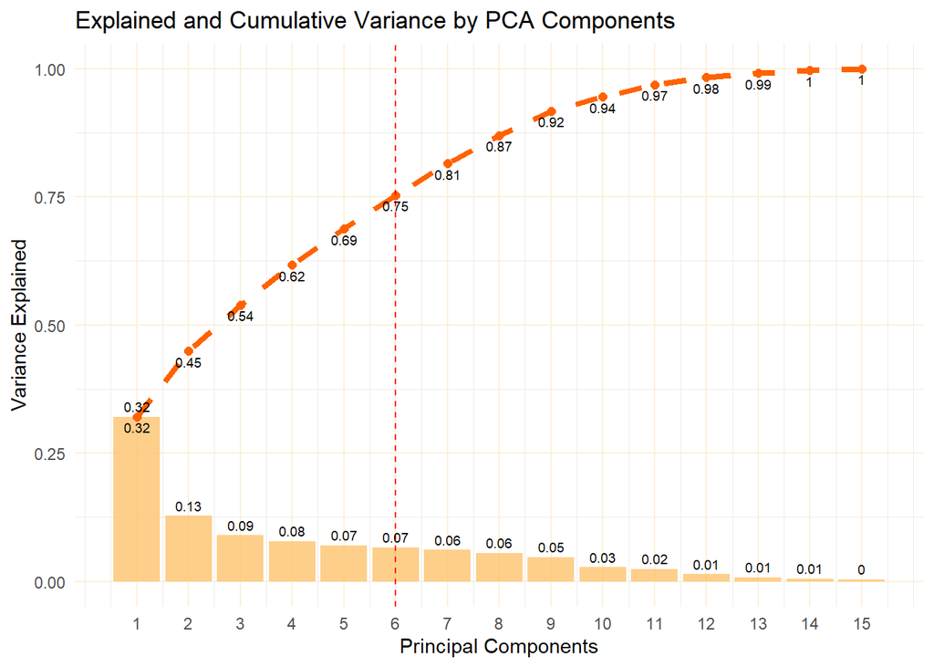

```r
# Extract the standard deviations of the principal components
std_devs <- pca_model$sdev

# Calculate the variance explained by each component
explained_variance <- (std_devs^2) / sum(std_devs^2)

# Calculate the cumulative variance
cumulative_variance <- cumsum(explained_variance)

# Set the number of components
num_components <- length(explained_variance)

# Create a data frame for plotting

pca_variance_df <- data.frame(
  Component = 1:num_components,
  ExplainedVariance = explained_variance,
  CumulativeVariance = cumulative_variance
)


# Plot the explained variance and cumulative variance

ggplot(pca_variance_df, aes(x = Component)) +
  geom_bar(aes(y = ExplainedVariance), stat = "identity", fill = "#fcc36d", alpha = 0.8) +
  geom_line(aes(y = CumulativeVariance), color = "#ff6200", size = 1.5, linetype = "dashed") +
  geom_point(aes(y = CumulativeVariance), color = "#ff6200", size = 2) +
  geom_vline(xintercept = 6, linetype = "dashed", color = "red") +
  labs(title = "Explained and Cumulative Variance by PCA Components",
       x = "Principal Components",
       y = "Variance Explained") +
  theme_minimal() +
  theme(panel.grid.major = element_line(color = "#fcf0dc")) +
   scale_x_continuous(breaks = 1:length(explained_variance)) +
  # Add annotations for explained variance and cumulative variance values
  geom_text(aes(y = ExplainedVariance, label = round(ExplainedVariance, 2)),
            vjust = -0.5, size = 2.5) +
  geom_text(aes(y = CumulativeVariance, label = round(CumulativeVariance, 2)),
            vjust = 1.5, size = 2.5)
```

- The plot and the cumulative explained variance values indicate how much of the total variance in the dataset is captured by each principal component, as well as the cumulative variance explained by the first n components.
- Variance is a measure of how much the data points differ from the mean. In PCA, it helps us understand how much of the dataset’s structure or information is captured by each principal component.
- Principal Component (PC): Each PC is an axis that is a linear combination of the original features. The first PC captures the maximum variance in the data, and each subsequent PC captures the next highest variance, subject to being orthogonal to the previous components.
- A common rule of thumb is to retain enough components to explain at least 70-90% of the variance, depending on the complexity you want to retain and how much information loss is acceptable.
- Here, we can observe that:
- The first component explains approximately 32% of the variance.
- The first two components together explain about 44% of the variance.
- The first three components explain approximately 53% of the variance, and so on.
- To choose the optimal number of components, we generally look for a point where adding another component doesn’t significantly increase the cumulative explained variance, often referred to as the “elbow point” in the curve.
- From the plot, we can see that the increase in cumulative variance starts to slow down after the 6th component (which captures about 75% of the total variance).
- Considering the context of customer segmentation, we want to retain a sufficient amount of information to identify distinct customer groups effectively. Therefore, retaining the first 6 components might be a balanced choice, as they together explain a substantial portion of the total variance while reducing the dimensionality of the dataset.

**K-means Clustering**

```r
library(tidymodels)
library(tidyclust)

# Data Preprocessing
customer_df <- customer_data_cleaned %>%
  mutate(Is_UK = as.factor(Is_UK))

# Recipe
customers_rec <- recipe(~., data = customer_df) %>%
  step_rm(CustomerID) %>%
  step_dummy(all_nominal_predictors(), one_hot = TRUE) %>%
  step_zv(all_numeric_predictors()) %>%
  step_normalize(all_numeric_predictors()) %>%
  step_pca(all_numeric_predictors(), num_comp = 4)

customers_rec
```

[output not shown]

```r
# Model specification
kmeans_spec <- k_means(num_clusters = tune()) %>%
  set_engine("stats")

kmeans_spec
```

```
## K Means Cluster Specification (partition)
##
## Main Arguments:
##   num_clusters = tune()
##
## Computational engine: stats
```

```r
# Workflow
customers_wf <- workflow() %>%
  add_model(kmeans_spec) %>%
  add_recipe(customers_rec)

customers_wf
```

```
## ══ Workflow ════════════════════════════════════════════════════════════════════
## Preprocessor: Recipe
## Model: k_means()
##
## ── Preprocessor ────────────────────────────────────────────────────────────────
## 5 Recipe Steps
##
## • step_rm()
## • step_dummy()
## • step_zv()
## • step_normalize()
## • step_pca()
##
## ── Model ───────────────────────────────────────────────────────────────────────
## K Means Cluster Specification (partition)
##
## Main Arguments:
##   num_clusters = tune()
##
## Computational engine: stats
```

```r
# Tuning
# Cross validation folds
set.seed(6132)
customer_folds <- vfold_cv(customer_df)

# Grid
set.seed(8712)
customer_res <- tune_cluster(
  customers_wf,
  resamples = customer_folds,
  grid = 10,
  metrics = cluster_metric_set(silhouette_avg)
)

customer_res
```

```
## # Tuning results
## # 10-fold cross-validation
## # A tibble: 10 × 4
##    splits             id     .metrics         .notes
##    <list>             <chr>  <list>           <list>
##  1 <split [3744/416]> Fold01 <tibble [8 × 5]> <tibble [0 × 3]>
##  2 <split [3744/416]> Fold02 <tibble [8 × 5]> <tibble [0 × 3]>
##  3 <split [3744/416]> Fold03 <tibble [8 × 5]> <tibble [0 × 3]>
##  4 <split [3744/416]> Fold04 <tibble [8 × 5]> <tibble [0 × 3]>
##  5 <split [3744/416]> Fold05 <tibble [8 × 5]> <tibble [0 × 3]>
##  6 <split [3744/416]> Fold06 <tibble [8 × 5]> <tibble [0 × 3]>
##  7 <split [3744/416]> Fold07 <tibble [8 × 5]> <tibble [0 × 3]>
##  8 <split [3744/416]> Fold08 <tibble [8 × 5]> <tibble [0 × 3]>
##  9 <split [3744/416]> Fold09 <tibble [8 × 5]> <tibble [0 × 3]>
## 10 <split [3744/416]> Fold10 <tibble [8 × 5]> <tibble [0 × 3]>
```

```r
customer_res %>%
  collect_metrics()
```

```
## # A tibble: 8 × 7
##   num_clusters .metric        .estimator  mean     n std_err .config
##          <int> <chr>          <chr>      <dbl> <int>   <dbl> <chr>
## 1            3 silhouette_avg standard   0.491    10 0.0162  Preprocessor1_Mode…
## 2           10 silhouette_avg standard   0.278    10 0.00365 Preprocessor1_Mode…
## 3            5 silhouette_avg standard   0.391    10 0.00132 Preprocessor1_Mode…
## 4            8 silhouette_avg standard   0.292    10 0.00752 Preprocessor1_Mode…
## 5            7 silhouette_avg standard   0.305    10 0.00224 Preprocessor1_Mode…
## 6            4 silhouette_avg standard   0.394    10 0.00722 Preprocessor1_Mode…
## 7            6 silhouette_avg standard   0.385    10 0.00884 Preprocessor1_Mode…
## 8            2 silhouette_avg standard   0.474    10 0.00362 Preprocessor1_Mode…
```

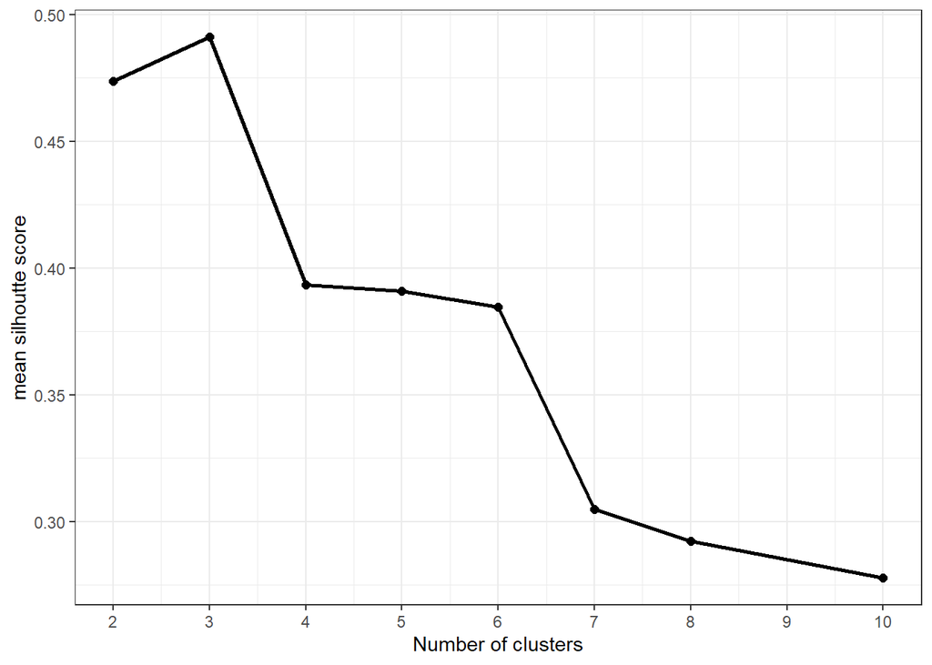

```r
# Plot the tuning results

customer_res %>%
  collect_metrics() %>%
  dplyr::select(num_clusters, mean) %>%
  ggplot(aes(num_clusters, mean)) +
  geom_point(size = 2) +
  geom_line(linewidth = 1.0) +
  theme_bw() +
  ylab("mean silhoutte score") +
  xlab("Number of clusters") +
  scale_x_continuous(breaks = 1:10)
```

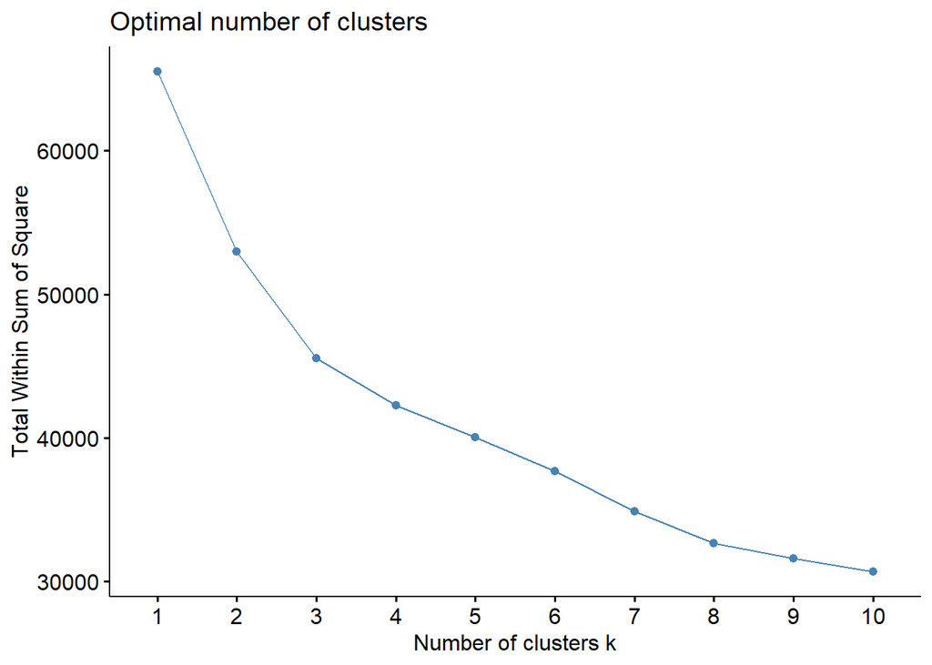

```r
# Using elbow and silhoutte graphs to determine number of clusters
library(factoextra)

# calculate distance
customer_dist <- get_dist(customer_data_scaled, method = "euclidean")

# Elbow method
fviz_nbclust(
  customer_data_scaled,
  kmeans,
  k.max = 10,
  method = "wss",
  diss = customer_dist
)
```

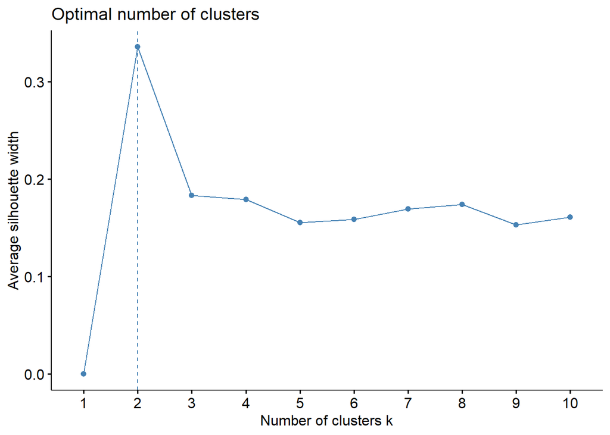

```r
# Silhoutte method
fviz_nbclust(
  customer_data_scaled,
  kmeans,
  k.max = 10,
  method = "silhouette",
  diss = customer_dist
)
```

- The Elbow method plot indicates that the optimal number of clusters is between 2 and 3, where as the silhouette plot indicates that the optimal number of clusters is 2.
- Although the silhouette plot suggests 2 clusters, the cross-validated tuning results provide a more reliable assessment, making 3 clusters the optimal choice.

```r
# Select optimal number of clusters and number of components, then finalize the workflow
best_clusters <- tibble(num_clusters = 3)
best_clusters
```

```
## # A tibble: 1 × 1
##   num_clusters
##          <dbl>
## 1            3
```

```r
clusters_final_wf <- finalize_workflow_tidyclust(customers_wf, best_clusters)
clusters_final_wf
```

```
## ══ Workflow ════════════════════════════════════════════════════════════════════
## Preprocessor: Recipe
## Model: k_means()
##
## ── Preprocessor ────────────────────────────────────────────────────────────────
## 5 Recipe Steps
##
## • step_rm()
## • step_dummy()
## • step_zv()
## • step_normalize()
## • step_pca()
##
## ── Model ───────────────────────────────────────────────────────────────────────
## K Means Cluster Specification (partition)
##
## Main Arguments:
##   num_clusters = 3
##
## Computational engine: stats
```

```r
# Fit the model
customers_fit <- fit(clusters_final_wf, data = customer_df)
customers_fit
```

[output not shown]

[output cut: 12 more lines]

```
## [1074] 3 1 1 1 1 1 1 3 1 1 1 3 1 1 1 1 3 1 3 3 1 1 1 2 1 1 3 1 1 1 1 1 1 1 1 1 1
## [1111] 1 1 1 1 1 3 1 1 1 3 1 1 3 1 1 1 1 1 1 1 1 1 3 3 1 1 1 3 1 1 1 1 1 3 1 3 1
## [1148] 3 1 1 1 1 3 3 1 3 1 1 1 3 3 1 1 1 1 1 1 2 1 1 1 1 1 1 1 1 3 3 3 1 1 1 1 1
## [1185] 1 3 1 1 1 1 1 1 1 1 1 1 1 3 3 1 3 3 1 1 1 1 3 1 1 1 1 1 1 1 1 1 1 3 1 1 1
## [1222] 3 1 1 3 1 3 1 1 3 1 1 1 3 1 3 1 1 1 1 1 3 1 3 1 1 1 1 1 3 1 3 1 1 1 1 1 1
## [1259] 1 1 1 1 1 1 1 1 1 1 1 1 1 1 1 1 1 1 1 3 1 1 1 1 3 1 1 1 3 3 1 3 1 1 1 1 1
## [1296] 1 3 1 1 1 1 3 1 1 1 3 3 1 1 1 3 1 1 1 3 3 1 1 3 1 1 3 1 1 1 3 1 1 1 3 3 1
## [1333] 1 1 3 3 1 3 3 1 1 1 1 2 3 1 1 1 1 3 2 1 3 1 1 3 1 1 1 3 3 3 1 1 3 1 1 3 3
## [1370] 3 3 1 1 1 3 1 1 1 1 1 1 3 1 1 1 1 2 1 1 1 1 1 1 1 1 1 1 1 1 1 1 1 1 1 1 1
## [1407] 1 3 1 3 3 1 1 1 1 1 1 1 1 1 1 1 1 3 3 3 1 3 1 3 1 3 1 1 1 1 1 1 1 1 1 1 3
## [1444] 1 3 1 1 1 3 1 1 1 1 1 3 1 1 1 1 1 1 2 1 1 1 1 1 1 1 1 1 1 1 3 3 1 1 1 1 1
## [1481] 1 1 1 1 1 1 1 1 1 1 1 1 1 1 1 1 1 3 1 1 1 1 1 1 1 1 3 3 1 1 1 1 1 1 1 1 1
##
## ...
## and 81 more lines.
```

```r
# To get the clusters

cluster_assignments <- predict(customers_fit, new_data = customer_df)
cluster_assignments
```

```
## # A tibble: 4,160 × 1
##    .pred_cluster
##    <fct>
##  1 Cluster_1
##  2 Cluster_2
##  3 Cluster_2
##  4 Cluster_2
##  5 Cluster_2
##  6 Cluster_2
##  7 Cluster_2
##  8 Cluster_2
##  9 Cluster_2
## 10 Cluster_2
## # ℹ 4,150 more rows
```

```r
# Observe the cluster in which each customer falls in

customer_df <- cluster_assignments %>%
  bind_cols(customer_df)

customer_df
```

```
## # A tibble: 4,160 × 17
##    .pred_cluster CustomerID Days_since_last_purchase total_transactions
##    <fct>         <chr>                         <dbl>              <int>
##  1 Cluster_1     12346                           325                  2
##  2 Cluster_2     12347                             2                  7
##  3 Cluster_2     12348                            75                  4
##  4 Cluster_2     12349                            18                  1
##  5 Cluster_2     12350                           310                  1
##  6 Cluster_2     12352                            36                  8
##  7 Cluster_2     12353                           204                  1
##  8 Cluster_2     12354                           232                  1
##  9 Cluster_2     12355                           214                  1
## 10 Cluster_2     12356                            22                  3
## # ℹ 4,150 more rows
## # ℹ 13 more variables: total_products <dbl>, total_spend <dbl>,
## #   average_transaction_value <dbl>, unique_products <int>,
## #   avg_days_btwn_purchases <dbl>, day <dbl>, Hour <int>, Is_UK <fct>,
## #   Cancellation_frequency <dbl>, Cancellation_rate <dbl>,
## #   monthly_spending_mean <dbl>, monthly_spending_std <dbl>,
## #   spending_trend <dbl>
```

```r
# Inspect the results

extract_cluster_assignment(customers_fit) %>% table()
```

```
## .cluster
## Cluster_1 Cluster_2 Cluster_3
##      3158       359       643
```

```r
extract_centroids(customers_fit)
```

```
## # A tibble: 3 × 5
##   .cluster     PC1    PC2     PC3     PC4
##   <fct>      <dbl>  <dbl>   <dbl>   <dbl>
## 1 Cluster_1 -0.818 -0.324 -0.236   0.0393
## 2 Cluster_2  0.241  3.94   2.14   -0.609
## 3 Cluster_3  3.88  -0.606 -0.0311  0.147
```

```r
# calculate distance
dists = dist(prep(customers_rec) %>% bake(new_data = NULL), method = "euclidean")

silhouette_avg(customers_fit, dists = dists)
```

```
## # A tibble: 1 × 3
##   .metric        .estimator .estimate
##   <chr>          <chr>          <dbl>
## 1 silhouette_avg standard       0.516
```

```r
#silhouette_avg_vec(customers_fit, dists = dists)
```

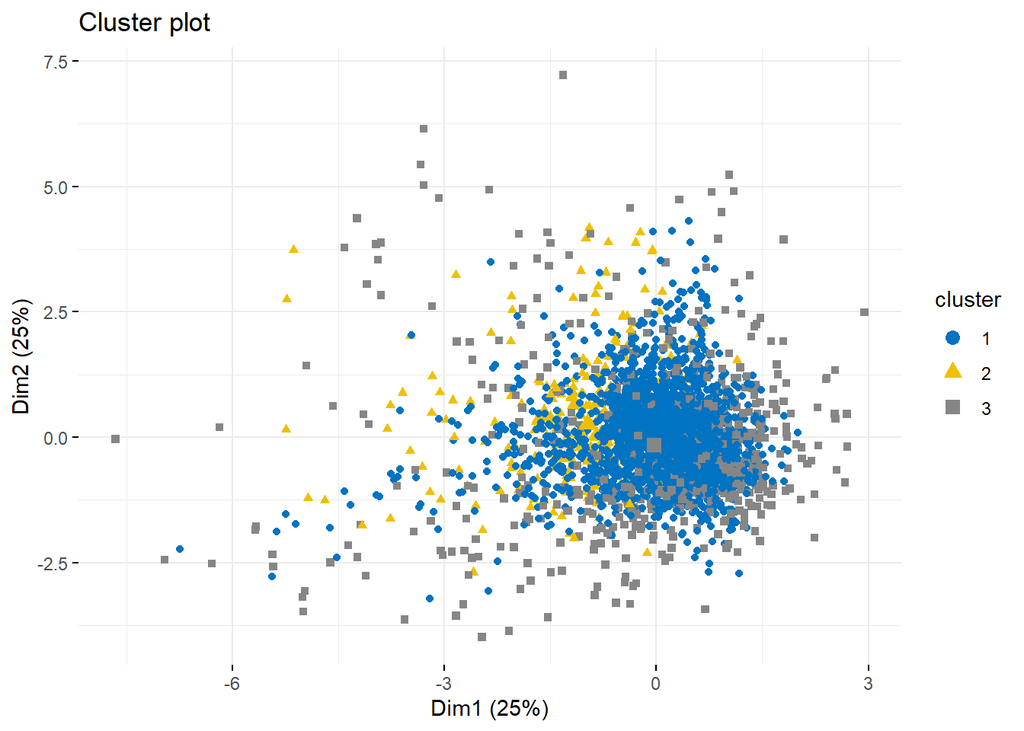

```r
#Visualize the clusters

customer_model <- extract_fit_parsnip(customers_fit)$fit

fviz_cluster(customer_model, data = prep(customers_rec) %>% bake(new_data = NULL),
             geom = "point",
             ellipse.type = "circle",
             palette = "jco",
             ggtheme = theme_minimal())
```

**Building a recommendation system**

```r
outliers_data
```

```
## # A tibble: 202 × 18
##    CustomerID Days_since_last_purchase total_transactions total_products
##    <chr>                         <dbl>              <int>          <dbl>
##  1 12357                            33                  1           2708
##  2 12378                           129                  1           2529
##  3 12406                            22                  3           1809
##  4 12409                            78                  7           5543
##  5 12415                            24                 24          76946
##  6 12428                            25                 11           3477
##  7 12432                            42                  4           1800
##  8 12433                             0                  7          11071
##  9 12435                            79                  2           2055
## 10 12438                            14                  2           1169
## # ℹ 192 more rows
## # ℹ 14 more variables: total_spend <dbl>, average_transaction_value <dbl>,
## #   unique_products <int>, avg_days_btwn_purchases <dbl>, day <dbl>,
## #   Hour <int>, Is_UK <dbl>, Cancellation_frequency <dbl>,
## #   Cancellation_rate <dbl>, monthly_spending_mean <dbl>,
## #   monthly_spending_std <dbl>, spending_trend <dbl>, Mahalanobis_Dist <dbl>,
## #   Is_Outlier <dbl>
```

```r
# Extract the CustomerIDs of the outliers and remove their transactions from the main dataframe

outlier_customer_ids <- unique(outliers_data$CustomerID)

df_filtered <- ecommerce %>%
  filter(!(CustomerID %in% outlier_customer_ids))

df_filtered
```

```
## # A tibble: 314,547 × 9
##    InvoiceNo StockCode Description        Quantity InvoiceDate         UnitPrice
##    <chr>     <chr>     <chr>                 <dbl> <dttm>                  <dbl>
##  1 536367    84879     ASSORTED COLOUR B…       32 2010-12-01 08:34:00      1.69
##  2 536367    22745     POPPY'S PLAYHOUSE…        6 2010-12-01 08:34:00      2.1
##  3 536367    22748     POPPY'S PLAYHOUSE…        6 2010-12-01 08:34:00      2.1
##  4 536367    22749     FELTCRAFT PRINCES…        8 2010-12-01 08:34:00      3.75
##  5 536367    22310     IVORY KNITTED MUG…        6 2010-12-01 08:34:00      1.65
##  6 536367    84969     BOX OF 6 ASSORTED…        6 2010-12-01 08:34:00      4.25
##  7 536367    22623     BOX OF VINTAGE JI…        3 2010-12-01 08:34:00      4.95
##  8 536367    22622     BOX OF VINTAGE AL…        2 2010-12-01 08:34:00      9.95
##  9 536367    21754     HOME BUILDING BLO…        3 2010-12-01 08:34:00      5.95
## 10 536367    21755     LOVE BUILDING BLO…        3 2010-12-01 08:34:00      5.95
## # ℹ 314,537 more rows
## # ℹ 3 more variables: CustomerID <dbl>, Country <chr>, Transaction_status <chr>
```

```r
# Convert CustomerID to numeric to ensure consistency

customer_df <- customer_df %>%
  mutate(CustomerID = as.numeric(CustomerID))
```

```r
# Merge the transaction data with the customer data to get the cluster information for each transaction

merged_data <- df_filtered %>%
  inner_join(customer_df, by = "CustomerID")

merged_data <- merged_data %>%
  rename(cluster = .pred_cluster)

merged_data
```

```
## # A tibble: 314,547 × 25
##    InvoiceNo StockCode Description        Quantity InvoiceDate         UnitPrice
##    <chr>     <chr>     <chr>                 <dbl> <dttm>                  <dbl>
##  1 536367    84879     ASSORTED COLOUR B…       32 2010-12-01 08:34:00      1.69
##  2 536367    22745     POPPY'S PLAYHOUSE…        6 2010-12-01 08:34:00      2.1
##  3 536367    22748     POPPY'S PLAYHOUSE…        6 2010-12-01 08:34:00      2.1
##  4 536367    22749     FELTCRAFT PRINCES…        8 2010-12-01 08:34:00      3.75
##  5 536367    22310     IVORY KNITTED MUG…        6 2010-12-01 08:34:00      1.65
##  6 536367    84969     BOX OF 6 ASSORTED…        6 2010-12-01 08:34:00      4.25
##  7 536367    22623     BOX OF VINTAGE JI…        3 2010-12-01 08:34:00      4.95
##  8 536367    22622     BOX OF VINTAGE AL…        2 2010-12-01 08:34:00      9.95
##  9 536367    21754     HOME BUILDING BLO…        3 2010-12-01 08:34:00      5.95
## 10 536367    21755     LOVE BUILDING BLO…        3 2010-12-01 08:34:00      5.95
## # ℹ 314,537 more rows
## # ℹ 19 more variables: CustomerID <dbl>, Country <chr>,
## #   Transaction_status <chr>, cluster <fct>, Days_since_last_purchase <dbl>,
## #   total_transactions <int>, total_products <dbl>, total_spend <dbl>,
## #   average_transaction_value <dbl>, unique_products <int>,
## #   avg_days_btwn_purchases <dbl>, day <dbl>, Hour <int>, Is_UK <fct>,
## #   Cancellation_frequency <dbl>, Cancellation_rate <dbl>, …
```

Identify the top 10 best-selling products in each cluster based on the total quantity sold

```r
# Group by cluster, StockCode, and Description to get total quantity sold

best_selling_products <- merged_data %>%
  group_by(cluster, StockCode, Description) %>%
  summarize(total_quantity = sum(Quantity, na.rm = TRUE)) %>%
  ungroup() %>%
  arrange(cluster, desc(total_quantity))

# Extract the top 10 products per cluster
top_products_per_cluster <- best_selling_products %>%
  group_by(cluster) %>%
  slice_head(n = 10) %>%
  ungroup()

top_products_per_cluster
```

```
## # A tibble: 30 × 4
##    cluster   StockCode Description                        total_quantity
##    <fct>     <chr>     <chr>                                       <dbl>
##  1 Cluster_1 84077     WORLD WAR 2 GLIDERS ASSTD DESIGNS           10951
##  2 Cluster_1 84879     ASSORTED COLOUR BIRD ORNAMENT               10775
##  3 Cluster_1 85123A    WHITE HANGING HEART T-LIGHT HOLDER           8645
##  4 Cluster_1 15036     ASSORTED COLOURS SILK FAN                    7292
##  5 Cluster_1 17003     BROCADE RING PURSE                           6093
##  6 Cluster_1 22178     VICTORIAN GLASS HANGING T-LIGHT              5972
##  7 Cluster_1 85099B    JUMBO BAG RED RETROSPOT                      5460
##  8 Cluster_1 21212     PACK OF 72 RETROSPOT CAKE CASES              5453
##  9 Cluster_1 22492     MINI PAINT SET VINTAGE                       5040
## 10 Cluster_1 84946     ANTIQUE SILVER T-LIGHT GLASS                 5023
## # ℹ 20 more rows
```

Create a record of products purchased by each customer in each cluster

```r
customer_purchases <- merged_data %>%
  group_by(CustomerID, cluster, StockCode) %>%
  summarize(total_quantity = sum(Quantity, na.rm = TRUE)) %>%
  ungroup()

customer_purchases
```

```
## # A tibble: 231,674 × 4
##    CustomerID cluster   StockCode total_quantity
##         <dbl> <fct>     <chr>              <dbl>
##  1      12346 Cluster_1 23166                  0
##  2      12347 Cluster_2 16008                 24
##  3      12347 Cluster_2 17021                 36
##  4      12347 Cluster_2 20665                  6
##  5      12347 Cluster_2 20719                 40
##  6      12347 Cluster_2 20780                 12
##  7      12347 Cluster_2 20782                  6
##  8      12347 Cluster_2 20966                 10
##  9      12347 Cluster_2 21035                  6
## 10      12347 Cluster_2 21041                 12
## # ℹ 231,664 more rows
```

Generate recommendations for each customer in each cluster

**First Approach**

```r
# Initialize an empty list to store recommendations

#recommendations <- list()

# Loop through each cluster
#for (cluster_id in unique(top_products_per_cluster$cluster)) {

  # Extract top products for the current cluster
#  top_products <- top_products_per_cluster %>%
#    filter(cluster == cluster_id)

  # Get customers belonging to the current cluster
#  customers_in_cluster <- merged_data %>%
#    filter(cluster == cluster_id) %>%
#    pull(CustomerID)

  # Loop through each customer in the cluster
#  for (customer in customers_in_cluster) {

    # Find products already purchased by the customer
#    customer_purchased_products <- customer_purchases %>%
#      filter(CustomerID == customer, cluster == cluster_id) %>%
#      pull(StockCode)

    # Identify top products the customer hasn't purchased yet
#    top_products_not_purchased <- top_products %>%
#      filter(!(StockCode %in% customer_purchased_products)) %>%
#      slice_head(n = 3)

    # Create a recommendation list for the customer
#    recommendation <- c(customer, cluster_id,
#                        top_products_not_purchased$StockCode,
#                        top_products_not_purchased$Description)

    # Append the recommendation to the list
#    recommendations <- append(recommendations, list(recommendation))
#  }
#}

#recommendations
```

Create a dataframe from the recommendations list and merge it with the original customer data

**Second Approach**

```r
# Generate recommendations for each customer in each cluster
# First, create a list of all top products for each cluster
all_top_products <- top_products_per_cluster %>%
  group_by(cluster) %>%
  summarize(top_products = list(StockCode), .groups = "drop")

all_top_products
```

```
## # A tibble: 3 × 2
##   cluster   top_products
##   <fct>     <list>
## 1 Cluster_1 <chr [10]>
## 2 Cluster_2 <chr [10]>
## 3 Cluster_3 <chr [10]>
```

```r
# Identify products already purchased by each customer
customer_purchases_summary <- customer_purchases %>%
  group_by(CustomerID, cluster) %>%
  summarize(purchased_products = list(StockCode), .groups = "drop")    # creates a list of product codes (stock codes) each customer has purchased.

customer_purchases_summary
```

```
## # A tibble: 4,160 × 3
##    CustomerID cluster   purchased_products
##         <dbl> <fct>     <list>
##  1      12346 Cluster_1 <chr [1]>
##  2      12347 Cluster_2 <chr [103]>
##  3      12348 Cluster_2 <chr [21]>
##  4      12349 Cluster_2 <chr [72]>
##  5      12350 Cluster_2 <chr [16]>
##  6      12352 Cluster_2 <chr [57]>
##  7      12353 Cluster_2 <chr [4]>
##  8      12354 Cluster_2 <chr [58]>
##  9      12355 Cluster_2 <chr [13]>
## 10      12356 Cluster_2 <chr [52]>
## # ℹ 4,150 more rows
```

```r
# Generate recommendations by removing purchased products from the top products for the cluster
recommendations_df <- customer_purchases_summary %>%
  left_join(all_top_products, by = "cluster") %>%
  rowwise() %>%
  mutate(recommendations = list(setdiff(top_products, purchased_products))) %>%
  ungroup() %>%
  mutate(recommendations = map(recommendations, ~ head(.x, 3))) %>%  # Limit to top 3 recommendations
  dplyr::select(CustomerID, cluster, recommendations) %>%
  unnest_wider(recommendations, names_sep = "_")

recommendations_df
```

```
## # A tibble: 4,160 × 5
##    CustomerID cluster   recommendations_1 recommendations_2 recommendations_3
##         <dbl> <fct>     <chr>             <chr>             <chr>
##  1      12346 Cluster_1 84077             84879             85123A
##  2      12347 Cluster_2 21212             22326             22629
##  3      12348 Cluster_2 21212             22492             23084
##  4      12349 Cluster_2 21212             22492             23084
##  5      12350 Cluster_2 21212             22492             23084
##  6      12352 Cluster_2 21212             22492             23084
##  7      12353 Cluster_2 21212             22492             23084
##  8      12354 Cluster_2 21212             22492             23084
##  9      12355 Cluster_2 21212             22492             23084
## 10      12356 Cluster_2 22492             23084             22326
## # ℹ 4,150 more rows
```

```r
# Merge the recommendations with the customer data
customer_data_with_recommendations <- merged_data %>%
  left_join(recommendations_df, by = c("CustomerID", "cluster"))

# Output the final recommendations
customer_data_with_recommendations
```

```
## # A tibble: 314,547 × 28
##    InvoiceNo StockCode Description        Quantity InvoiceDate         UnitPrice
##    <chr>     <chr>     <chr>                 <dbl> <dttm>                  <dbl>
##  1 536367    84879     ASSORTED COLOUR B…       32 2010-12-01 08:34:00      1.69
##  2 536367    22745     POPPY'S PLAYHOUSE…        6 2010-12-01 08:34:00      2.1
##  3 536367    22748     POPPY'S PLAYHOUSE…        6 2010-12-01 08:34:00      2.1
##  4 536367    22749     FELTCRAFT PRINCES…        8 2010-12-01 08:34:00      3.75
##  5 536367    22310     IVORY KNITTED MUG…        6 2010-12-01 08:34:00      1.65
##  6 536367    84969     BOX OF 6 ASSORTED…        6 2010-12-01 08:34:00      4.25
##  7 536367    22623     BOX OF VINTAGE JI…        3 2010-12-01 08:34:00      4.95
##  8 536367    22622     BOX OF VINTAGE AL…        2 2010-12-01 08:34:00      9.95
##  9 536367    21754     HOME BUILDING BLO…        3 2010-12-01 08:34:00      5.95
## 10 536367    21755     LOVE BUILDING BLO…        3 2010-12-01 08:34:00      5.95
## # ℹ 314,537 more rows
## # ℹ 22 more variables: CustomerID <dbl>, Country <chr>,
## #   Transaction_status <chr>, cluster <fct>, Days_since_last_purchase <dbl>,
## #   total_transactions <int>, total_products <dbl>, total_spend <dbl>,
## #   average_transaction_value <dbl>, unique_products <int>,
## #   avg_days_btwn_purchases <dbl>, day <dbl>, Hour <int>, Is_UK <fct>,
## #   Cancellation_frequency <dbl>, Cancellation_rate <dbl>, …
```

- left_join(all_top_products, by = “cluster”) merges the top products for each cluster with each customer’s purchase history. This ensures that we have both the top products and the customer’s purchased products available in the same row for each CustomerID and cluster.
- rowwise() ensures that the subsequent operations happen on a row-by-row basis rather than column-wise.
- mutate(recommendations = list(setdiff(top_products, purchased_products))) generates recommendations by using setdiff(), which identifies products from top_products that the customer hasn’t purchased yet. The result is a list of unpurchased top products for each customer.
- mutate(recommendations = map(recommendations, ~ head(.x, 3))) limits the number of recommendations to the top 3 products. map() is used to apply the head() function to each list of recommendations, selecting the first 3 products.